# Sheikh M Muneer-MP2-Final

## Importing libraries:

```r
library(dplyr)
library(tidyverse)
library(openintro)
library(UsingR)
library(statsr)
library(broom)
library(MASS)
library(car)
library(olsrr)
```

```r
library(ggplot2)
```

## Import Training Dataset:

```r
df_ames <- readr::read_csv("train.csv")
head(df_ames)
```

```
## # A tibble: 6 x 81
##      Id MSSubClass MSZoning LotFrontage LotArea Street Alley LotShape
##   <dbl>      <dbl> <chr>          <dbl>   <dbl> <chr>  <chr> <chr>
## 1     1         60 RL                65    8450 Pave   <NA>  Reg
## 2     2         20 RL                80    9600 Pave   <NA>  Reg
## 3     3         60 RL                68   11250 Pave   <NA>  IR1
## 4     4         70 RL                60    9550 Pave   <NA>  IR1
## 5     5         60 RL                84   14260 Pave   <NA>  IR1
## 6     6         50 RL                85   14115 Pave   <NA>  IR1
## # ... with 73 more variables: LandContour <chr>, Utilities <chr>,
## #   LotConfig <chr>, LandSlope <chr>, Neighborhood <chr>, Condition1 <chr>,
## #   Condition2 <chr>, BldgType <chr>, HouseStyle <chr>, OverallQual <dbl>,
## #   OverallCond <dbl>, YearBuilt <dbl>, YearRemodAdd <dbl>, RoofStyle <chr>,
## #   RoofMatl <chr>, Exterior1st <chr>, Exterior2nd <chr>, MasVnrType <chr>,
## #   MasVnrArea <dbl>, ExterQual <chr>, ExterCond <chr>, Foundation <chr>,
## #   BsmtQual <chr>, BsmtCond <chr>, BsmtExposure <chr>, BsmtFinType1 <chr>,
## #   BsmtFinSF1 <dbl>, BsmtFinType2 <chr>, BsmtFinSF2 <dbl>, BsmtUnfSF <dbl>,
## #   TotalBsmtSF <dbl>, Heating <chr>, HeatingQC <chr>, CentralAir <chr>,
## #   Electrical <chr>, `1stFlrSF` <dbl>, `2ndFlrSF` <dbl>, LowQualFinSF <dbl>,
## #   GrLivArea <dbl>, BsmtFullBath <dbl>, BsmtHalfBath <dbl>, FullBath <dbl>,
## #   HalfBath <dbl>, BedroomAbvGr <dbl>, KitchenAbvGr <dbl>, KitchenQual <chr>,
## #   TotRmsAbvGrd <dbl>, Functional <chr>, Fireplaces <dbl>, FireplaceQu <chr>,
## #   GarageType <chr>, GarageYrBlt <dbl>, GarageFinish <chr>, GarageCars <dbl>,
## #   GarageArea <dbl>, GarageQual <chr>, GarageCond <chr>, PavedDrive <chr>,
## #   WoodDeckSF <dbl>, OpenPorchSF <dbl>, EnclosedPorch <dbl>,
## #   `3SsnPorch` <dbl>, ScreenPorch <dbl>, PoolArea <dbl>, PoolQC <chr>,
## #   Fence <chr>, MiscFeature <chr>, MiscVal <dbl>, MoSold <dbl>, YrSold <dbl>,
## #   SaleType <chr>, SaleCondition <chr>, SalePrice <dbl>
```

## Import Test Dataset:

```r
df_test <- readr::read_csv("test.csv")
head(df_test)
```

```
## # A tibble: 6 x 80
##      Id MSSubClass MSZoning LotFrontage LotArea Street Alley LotShape
##   <dbl>      <dbl> <chr>          <dbl>   <dbl> <chr>  <chr> <chr>
## 1  1461         20 RH                80   11622 Pave   <NA>  Reg
## 2  1462         20 RL                81   14267 Pave   <NA>  IR1
## 3  1463         60 RL                74   13830 Pave   <NA>  IR1
## 4  1464         60 RL                78    9978 Pave   <NA>  IR1
## 5  1465        120 RL                43    5005 Pave   <NA>  IR1
## 6  1466         60 RL                75   10000 Pave   <NA>  IR1
## # ... with 72 more variables: LandContour <chr>, Utilities <chr>,
## #   LotConfig <chr>, LandSlope <chr>, Neighborhood <chr>, Condition1 <chr>,
## #   Condition2 <chr>, BldgType <chr>, HouseStyle <chr>, OverallQual <dbl>,
## #   OverallCond <dbl>, YearBuilt <dbl>, YearRemodAdd <dbl>, RoofStyle <chr>,
## #   RoofMatl <chr>, Exterior1st <chr>, Exterior2nd <chr>, MasVnrType <chr>,
## #   MasVnrArea <dbl>, ExterQual <chr>, ExterCond <chr>, Foundation <chr>,
## #   BsmtQual <chr>, BsmtCond <chr>, BsmtExposure <chr>, BsmtFinType1 <chr>,
## #   BsmtFinSF1 <dbl>, BsmtFinType2 <chr>, BsmtFinSF2 <dbl>, BsmtUnfSF <dbl>,
## #   TotalBsmtSF <dbl>, Heating <chr>, HeatingQC <chr>, CentralAir <chr>,
## #   Electrical <chr>, `1stFlrSF` <dbl>, `2ndFlrSF` <dbl>, LowQualFinSF <dbl>,
## #   GrLivArea <dbl>, BsmtFullBath <dbl>, BsmtHalfBath <dbl>, FullBath <dbl>,
## #   HalfBath <dbl>, BedroomAbvGr <dbl>, KitchenAbvGr <dbl>, KitchenQual <chr>,
## #   TotRmsAbvGrd <dbl>, Functional <chr>, Fireplaces <dbl>, FireplaceQu <chr>,
## #   GarageType <chr>, GarageYrBlt <dbl>, GarageFinish <chr>, GarageCars <dbl>,
## #   GarageArea <dbl>, GarageQual <chr>, GarageCond <chr>, PavedDrive <chr>,
## #   WoodDeckSF <dbl>, OpenPorchSF <dbl>, EnclosedPorch <dbl>,
## #   `3SsnPorch` <dbl>, ScreenPorch <dbl>, PoolArea <dbl>, PoolQC <chr>,
## #   Fence <chr>, MiscFeature <chr>, MiscVal <dbl>, MoSold <dbl>, YrSold <dbl>,
## #   SaleType <chr>, SaleCondition <chr>
```

## Data Types of DataSet:

```r
str(df_ames)
```

```
## Classes 'spec_tbl_df', 'tbl_df', 'tbl' and 'data.frame': 1460 obs. of  81 variables:
##  $ Id           : num  1 2 3 4 5 6 7 8 9 10 ...
##  $ MSSubClass   : num  60 20 60 70 60 50 20 60 50 190 ...
##  $ MSZoning     : chr  "RL" "RL" "RL" "RL" ...
##  $ LotFrontage  : num  65 80 68 60 84 85 75 NA 51 50 ...
##  $ LotArea      : num  8450 9600 11250 9550 14260 ...
##  $ Street       : chr  "Pave" "Pave" "Pave" "Pave" ...
##  $ Alley        : chr  NA NA NA NA ...
##  $ LotShape     : chr  "Reg" "Reg" "IR1" "IR1" ...
##  $ LandContour  : chr  "Lvl" "Lvl" "Lvl" "Lvl" ...
##  $ Utilities    : chr  "AllPub" "AllPub" "AllPub" "AllPub" ...
##  $ LotConfig    : chr  "Inside" "FR2" "Inside" "Corner" ...
##  $ LandSlope    : chr  "Gtl" "Gtl" "Gtl" "Gtl" ...
##  $ Neighborhood : chr  "CollgCr" "Veenker" "CollgCr" "Crawfor" ...
##  $ Condition1   : chr  "Norm" "Feedr" "Norm" "Norm" ...
##  $ Condition2   : chr  "Norm" "Norm" "Norm" "Norm" ...
##  $ BldgType     : chr  "1Fam" "1Fam" "1Fam" "1Fam" ...
##  $ HouseStyle   : chr  "2Story" "1Story" "2Story" "2Story" ...
##  $ OverallQual  : num  7 6 7 7 8 5 8 7 7 5 ...
##  $ OverallCond  : num  5 8 5 5 5 5 5 6 5 6 ...
##  $ YearBuilt    : num  2003 1976 2001 1915 2000 ...
##  $ YearRemodAdd : num  2003 1976 2002 1970 2000 ...
##  $ RoofStyle    : chr  "Gable" "Gable" "Gable" "Gable" ...
##  $ RoofMatl     : chr  "CompShg" "CompShg" "CompShg" "CompShg" ...
##  $ Exterior1st  : chr  "VinylSd" "MetalSd" "VinylSd" "Wd Sdng" ...
##  $ Exterior2nd  : chr  "VinylSd" "MetalSd" "VinylSd" "Wd Shng" ...
##  $ MasVnrType   : chr  "BrkFace" "None" "BrkFace" "None" ...
##  $ MasVnrArea   : num  196 0 162 0 350 0 186 240 0 0 ...
##  $ ExterQual    : chr  "Gd" "TA" "Gd" "TA" ...
##  $ ExterCond    : chr  "TA" "TA" "TA" "TA" ...
##  $ Foundation   : chr  "PConc" "CBlock" "PConc" "BrkTil" ...
##  $ BsmtQual     : chr  "Gd" "Gd" "Gd" "TA" ...
##  $ BsmtCond     : chr  "TA" "TA" "TA" "Gd" ...
##  $ BsmtExposure : chr  "No" "Gd" "Mn" "No" ...
##  $ BsmtFinType1 : chr  "GLQ" "ALQ" "GLQ" "ALQ" ...
##  $ BsmtFinSF1   : num  706 978 486 216 655 ...
##  $ BsmtFinType2 : chr  "Unf" "Unf" "Unf" "Unf" ...
##  $ BsmtFinSF2   : num  0 0 0 0 0 0 0 32 0 0 ...
##  $ BsmtUnfSF    : num  150 284 434 540 490 64 317 216 952 140 ...
##  $ TotalBsmtSF  : num  856 1262 920 756 1145 ...
```

[output cut: 111 more lines]

```
##   ..   OpenPorchSF = col_double(),
##   ..   EnclosedPorch = col_double(),
##   ..   `3SsnPorch` = col_double(),
##   ..   ScreenPorch = col_double(),
##   ..   PoolArea = col_double(),
##   ..   PoolQC = col_character(),
##   ..   Fence = col_character(),
##   ..   MiscFeature = col_character(),
##   ..   MiscVal = col_double(),
##   ..   MoSold = col_double(),
##   ..   YrSold = col_double(),
##   ..   SaleType = col_character(),
##   ..   SaleCondition = col_character(),
##   ..   SalePrice = col_double()
##   .. )
```

## Dimension of DataSet:

```r
dim(df_ames)
```

```
## [1] 1460   81
```

There are 1460 Rows and 81 Columns

## Summary of DataSet:

```r
summary(df_ames)
```

```
##        Id           MSSubClass      MSZoning          LotFrontage
##  Min.   :   1.0   Min.   : 20.0   Length:1460        Min.   : 21.00
##  1st Qu.: 365.8   1st Qu.: 20.0   Class :character   1st Qu.: 59.00
##  Median : 730.5   Median : 50.0   Mode  :character   Median : 69.00
##  Mean   : 730.5   Mean   : 56.9                      Mean   : 70.05
##  3rd Qu.:1095.2   3rd Qu.: 70.0                      3rd Qu.: 80.00
##  Max.   :1460.0   Max.   :190.0                      Max.   :313.00
##                                                      NA's   :259
##     LotArea          Street             Alley             LotShape
##  Min.   :  1300   Length:1460        Length:1460        Length:1460
##  1st Qu.:  7554   Class :character   Class :character   Class :character
##  Median :  9478   Mode  :character   Mode  :character   Mode  :character
##  Mean   : 10517
##  3rd Qu.: 11602
##  Max.   :215245
##
##  LandContour         Utilities          LotConfig          LandSlope
##  Length:1460        Length:1460        Length:1460        Length:1460
##  Class :character   Class :character   Class :character   Class :character
##  Mode  :character   Mode  :character   Mode  :character   Mode  :character
##
##
##
##
##  Neighborhood        Condition1         Condition2          BldgType
##  Length:1460        Length:1460        Length:1460        Length:1460
##  Class :character   Class :character   Class :character   Class :character
##  Mode  :character   Mode  :character   Mode  :character   Mode  :character
##
##
##
##
##   HouseStyle         OverallQual      OverallCond      YearBuilt
##  Length:1460        Min.   : 1.000   Min.   :1.000   Min.   :1872
##  Class :character   1st Qu.: 5.000   1st Qu.:5.000   1st Qu.:1954
##  Mode  :character   Median : 6.000   Median :5.000   Median :1973
##                     Mean   : 6.099   Mean   :5.575   Mean   :1971
##                     3rd Qu.: 7.000   3rd Qu.:6.000   3rd Qu.:2000
##                     Max.   :10.000   Max.   :9.000   Max.   :2010
##
```

[output cut: 113 more lines]

```
##  Min.   : 1.000   Min.   :2006   Length:1460        Length:1460
##  1st Qu.: 5.000   1st Qu.:2007   Class :character   Class :character
##  Median : 6.000   Median :2008   Mode  :character   Mode  :character
##  Mean   : 6.322   Mean   :2008
##  3rd Qu.: 8.000   3rd Qu.:2009
##  Max.   :12.000   Max.   :2010
##
##    SalePrice
##  Min.   : 34900
##  1st Qu.:129975
##  Median :163000
##  Mean   :180921
##  3rd Qu.:214000
##  Max.   :755000
##
```

# Univariate Analysis:

```r
class(df_ames$MSSubClass)
```

```
## [1] "numeric"
```

```r
unique(df_ames$MSSubClass)
```

```
##  [1]  60  20  70  50 190  45  90 120  30  85  80 160  75 180  40
```

```r
df_ames$MSSubClass <- as.character(df_ames$MSSubClass)
class(df_ames$MSSubClass)
```

```
## [1] "character"
```

As MSSubClass respresentation is of Categorical so We will convert this into Character Representation.

# Data Cleaning and Imputation:

We are Observing How Manny Columns have Null Values in Specific Columns.

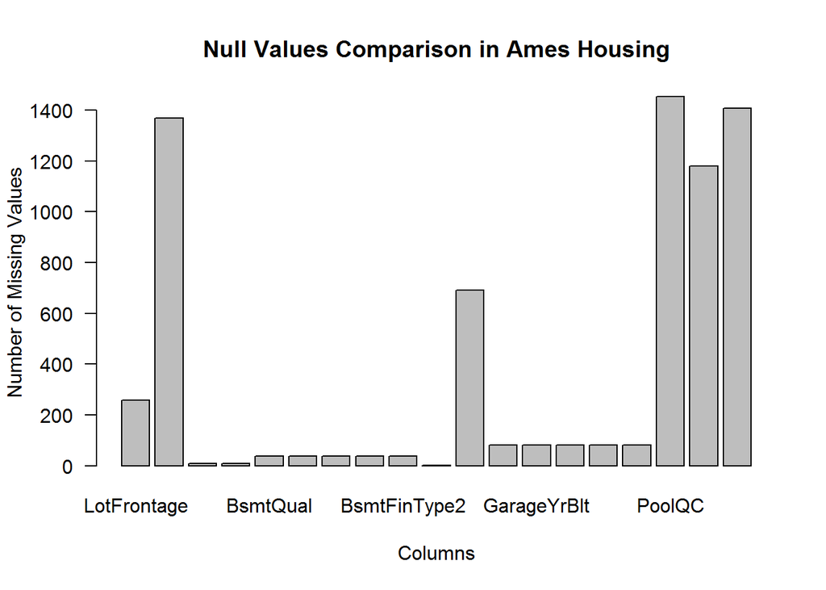

```r
All_nulls  <- colSums(is.na(df_ames))
All_nulls  <- All_nulls[All_nulls>0]
barplot(All_nulls, main="Null Values Comparison in Ames Housing",xlab="Columns",ylab="Number of Missing Values",las=1,col=8)
```

## Mode Function:

We are making Mode Function to Impute Mode on Categorical Columns where values are Nulls.

```r
getmode <- function(v) {
  uniqv <- unique(v)
  uniqv[which.max(tabulate(match(v, uniqv)))]
}
```

```r
ames_train_int <- dplyr::select_if(df_ames, is.numeric)
ames_train_int
```

```
## # A tibble: 1,460 x 37
##       Id LotFrontage LotArea OverallQual OverallCond YearBuilt YearRemodAdd
##    <dbl>       <dbl>   <dbl>       <dbl>       <dbl>     <dbl>        <dbl>
##  1     1          65    8450           7           5      2003         2003
##  2     2          80    9600           6           8      1976         1976
##  3     3          68   11250           7           5      2001         2002
##  4     4          60    9550           7           5      1915         1970
##  5     5          84   14260           8           5      2000         2000
##  6     6          85   14115           5           5      1993         1995
##  7     7          75   10084           8           5      2004         2005
##  8     8          NA   10382           7           6      1973         1973
##  9     9          51    6120           7           5      1931         1950
## 10    10          50    7420           5           6      1939         1950
## # ... with 1,450 more rows, and 30 more variables: MasVnrArea <dbl>,
## #   BsmtFinSF1 <dbl>, BsmtFinSF2 <dbl>, BsmtUnfSF <dbl>, TotalBsmtSF <dbl>,
## #   `1stFlrSF` <dbl>, `2ndFlrSF` <dbl>, LowQualFinSF <dbl>, GrLivArea <dbl>,
## #   BsmtFullBath <dbl>, BsmtHalfBath <dbl>, FullBath <dbl>, HalfBath <dbl>,
## #   BedroomAbvGr <dbl>, KitchenAbvGr <dbl>, TotRmsAbvGrd <dbl>,
## #   Fireplaces <dbl>, GarageYrBlt <dbl>, GarageCars <dbl>, GarageArea <dbl>,
## #   WoodDeckSF <dbl>, OpenPorchSF <dbl>, EnclosedPorch <dbl>,
## #   `3SsnPorch` <dbl>, ScreenPorch <dbl>, PoolArea <dbl>, MiscVal <dbl>,
## #   MoSold <dbl>, YrSold <dbl>, SalePrice <dbl>
```

```r
ames_train_int[ames_train_int=="NA"] <-  lapply(ames_train_int, mean, na.rm = TRUE)
ames_train_int[ames_train_int==""] <-    lapply(ames_train_int, mean, na.rm = TRUE)
dim(ames_train_int)
```

```
## [1] 1460   37
```

Dealing of Missing categorical values with Mode Imputation for Categorical Variables.

```r
ames_train_fac <- dplyr::select_if(df_ames, is_character)
ames_train_fac <- sapply(ames_train_fac, as.character)
ames_train_fac[is.na(ames_train_fac)] <-   getmode(ames_train_fac)
ames_train_fac[ames_train_fac==""]<- getmode(ames_train_fac)
ames_train_fac <- data.frame(ames_train_fac)
dim(ames_train_fac)
```

```
## [1] 1460   44
```

Merging both Numerical and Categoricals Variables in Training DataFrame

```r
df_ames <- cbind(ames_train_int, ames_train_fac)
head(df_ames)
```

```
##   Id LotFrontage LotArea OverallQual OverallCond YearBuilt YearRemodAdd
## 1  1          65    8450           7           5      2003         2003
## 2  2          80    9600           6           8      1976         1976
## 3  3          68   11250           7           5      2001         2002
## 4  4          60    9550           7           5      1915         1970
## 5  5          84   14260           8           5      2000         2000
## 6  6          85   14115           5           5      1993         1995
##   MasVnrArea BsmtFinSF1 BsmtFinSF2 BsmtUnfSF TotalBsmtSF 1stFlrSF 2ndFlrSF
## 1        196        706          0       150         856      856      854
## 2          0        978          0       284        1262     1262        0
## 3        162        486          0       434         920      920      866
## 4          0        216          0       540         756      961      756
## 5        350        655          0       490        1145     1145     1053
## 6          0        732          0        64         796      796      566
##   LowQualFinSF GrLivArea BsmtFullBath BsmtHalfBath FullBath HalfBath
```

[output cut: 69 more lines]

# Exploratory Data Analysis:

View Sale Price Distribution.

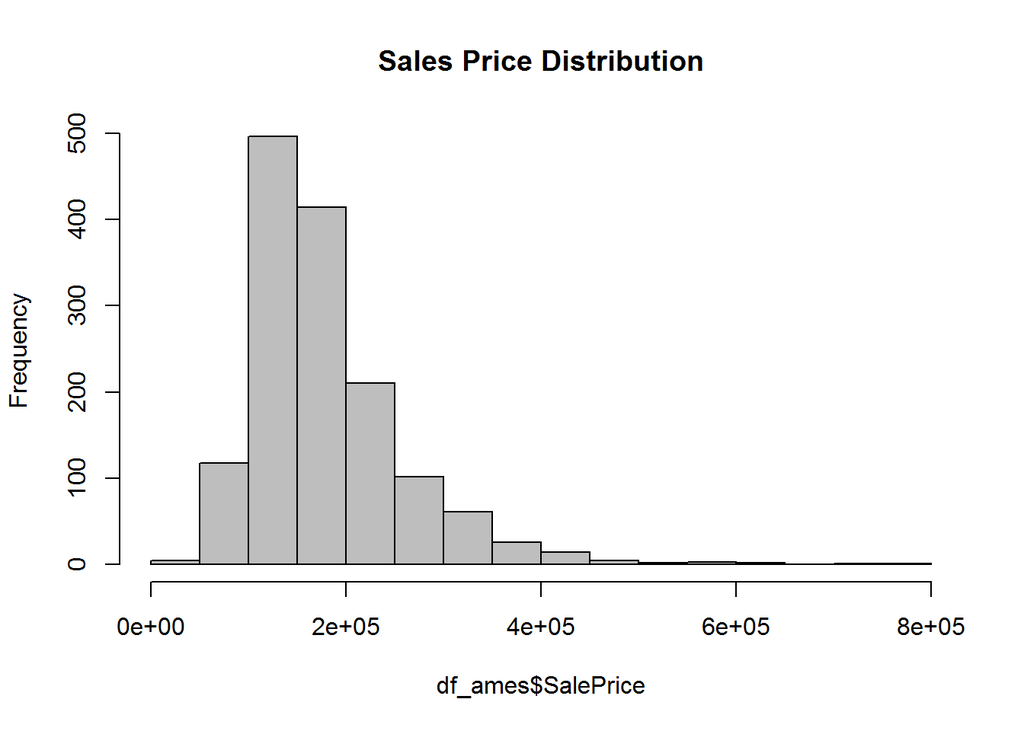

```r
hist(df_ames$SalePrice,main="Sales Price Distribution",col=8)
```

Since Sale Price is not linearly Distributed we will use log to Normally Distribute this as Linear Model will Work Perfect on Linear Distribution.

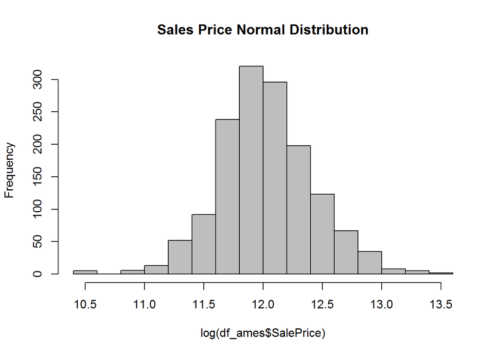

```r
hist(log(df_ames$SalePrice),main="Sales Price Normal Distribution",col=8)
```

Analysis of Sale Price by Sale Condition

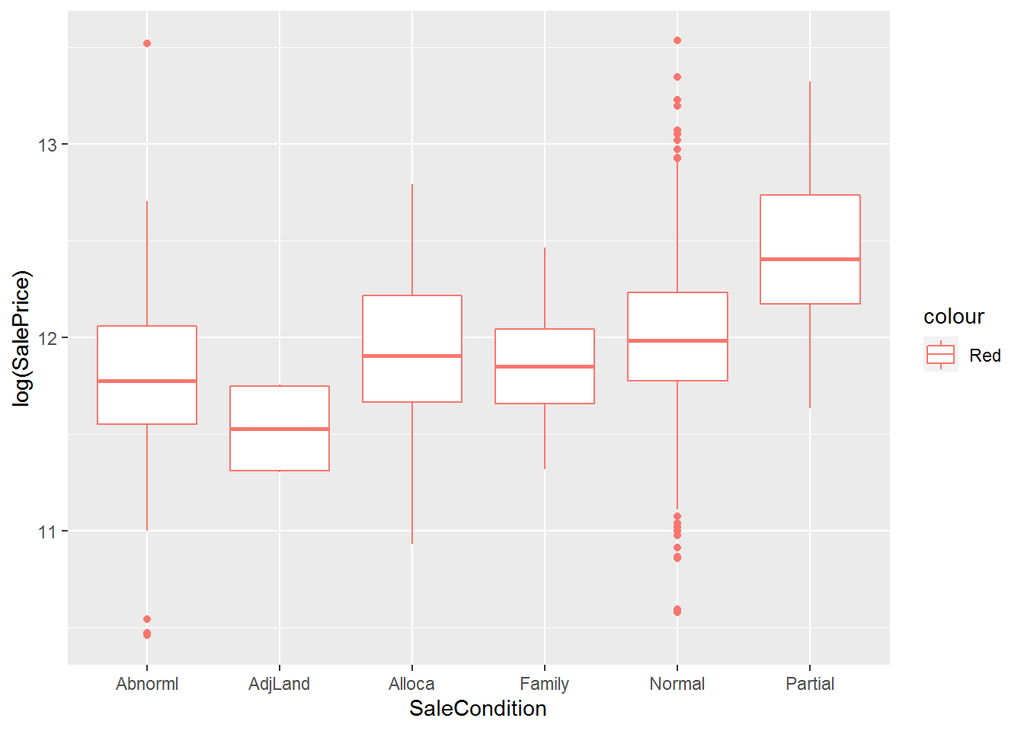

```r
ggplot(df_ames,aes(SaleCondition,log(SalePrice))) +  geom_boxplot(aes(col='Red'))
```

We can See that Partial Sales Condition have High Sale Price.Normal and Abnormal have Outliers values.

Analysis of Sale Price by Sale Type.

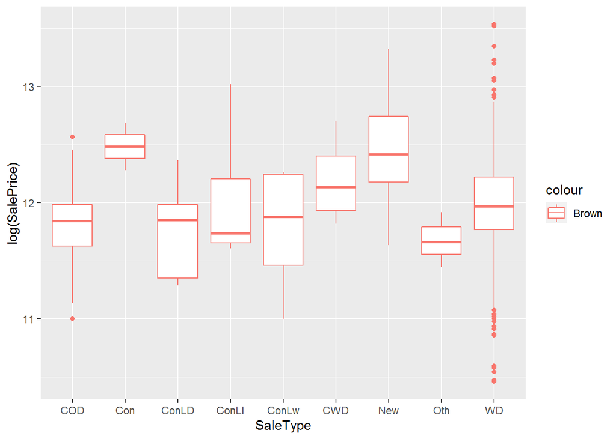

```r
ggplot(df_ames,aes(SaleType,log(SalePrice))) +  geom_boxplot(aes(col='Brown'))
```

Analysis of Sale Price by MSSubClass

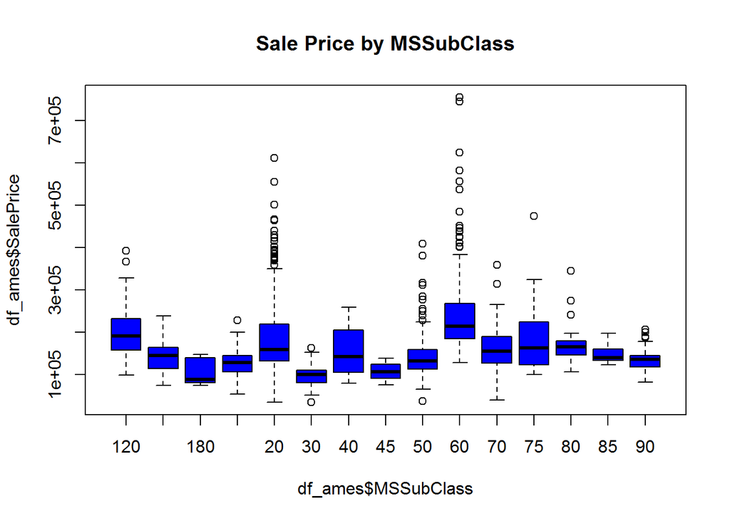

```r
boxplot(df_ames$SalePrice ~ df_ames$MSSubClass,main="Sale Price by MSSubClass",col="Blue")
```

# Linear Regression Modelling :

I will Exclude Utilities Column which have Only 1 level having same Value in All Rows which will not permit our linear model to fit Perfectly.I am going to model Full Linear Model.

```r
df_ames = subset(df_ames, select=-c(Utilities))
full_model_lm <- lm(log(SalePrice)~., data=df_ames)
summary(full_model_lm)
```

```
##
## Call:
## lm(formula = log(SalePrice) ~ ., data = df_ames)
##
## Residuals:
##      Min       1Q   Median       3Q      Max
## -0.68364 -0.04459  0.00000  0.04664  0.68364
##
## Coefficients: (6 not defined because of singularities)
##                        Estimate Std. Error t value Pr(>|t|)
## (Intercept)           5.760e+00  5.831e+00   0.988 0.323583
## Id                   -6.875e-06  7.976e-06  -0.862 0.388966
## LotFrontage           4.678e-04  2.423e-04   1.931 0.053856 .
## LotArea               2.864e-06  6.502e-07   4.405 1.19e-05 ***
## OverallQual           3.789e-02  5.566e-03   6.808 1.84e-11 ***
## OverallCond           3.683e-02  4.935e-03   7.464 2.04e-13 ***
## YearBuilt             1.529e-03  4.696e-04   3.256 0.001172 **
## YearRemodAdd          8.005e-04  3.068e-04   2.609 0.009227 **
## MasVnrArea            2.398e-05  2.879e-05   0.833 0.405154
## BsmtFinSF1            1.471e-04  2.940e-05   5.004 6.80e-07 ***
## BsmtFinSF2            1.276e-04  4.909e-05   2.600 0.009473 **
## BsmtUnfSF             8.254e-05  2.773e-05   2.977 0.002994 **
## TotalBsmtSF                  NA         NA      NA       NA
## `1stFlrSF`            2.090e-04  3.103e-05   6.737 2.95e-11 ***
## `2ndFlrSF`            1.922e-04  3.104e-05   6.192 9.15e-10 ***
## LowQualFinSF          9.588e-06  1.346e-04   0.071 0.943250
## GrLivArea                    NA         NA      NA       NA
## BsmtFullBath          1.792e-02  1.035e-02   1.732 0.083642 .
## BsmtHalfBath          2.324e-03  1.589e-02   0.146 0.883770
## FullBath              2.727e-02  1.199e-02   2.275 0.023171 *
## HalfBath              2.994e-02  1.128e-02   2.654 0.008089 **
## BedroomAbvGr          4.335e-03  7.647e-03   0.567 0.570895
## KitchenAbvGr         -4.437e-02  3.823e-02  -1.161 0.246113
## TotRmsAbvGrd          5.883e-03  5.049e-03   1.165 0.244254
## Fireplaces            2.446e-02  8.627e-03   2.835 0.004693 **
## GarageYrBlt          -3.346e-05  3.179e-04  -0.105 0.916210
## GarageCars            2.683e-02  1.154e-02   2.325 0.020296 *
## GarageArea            1.206e-04  3.987e-05   3.026 0.002553 **
## WoodDeckSF            9.336e-05  3.146e-05   2.968 0.003083 **
## OpenPorchSF           7.477e-05  6.463e-05   1.157 0.247658
```

[output cut: 220 more lines]

```
## SaleTypeNew           5.203e-02  7.484e-02   0.695 0.487092
## SaleTypeOth           1.342e-01  1.107e-01   1.211 0.226081
## SaleTypeWD           -2.150e-02  2.161e-02  -0.995 0.319910
## SaleConditionAdjLand  2.276e-01  1.146e-01   1.985 0.047415 *
## SaleConditionAlloca   3.303e-02  4.950e-02   0.667 0.504808
## SaleConditionFamily   8.731e-03  2.993e-02   0.292 0.770585
## SaleConditionNormal   6.263e-02  1.550e-02   4.040 5.81e-05 ***
## SaleConditionPartial  2.750e-02  7.220e-02   0.381 0.703329
## ---
## Signif. codes:  0 '***' 0.001 '**' 0.01 '*' 0.05 '.' 0.1 ' ' 1
##
## Residual standard error: 0.0999 on 869 degrees of freedom
##   (339 observations deleted due to missingness)
## Multiple R-squared:  0.9508, Adjusted R-squared:  0.9366
## F-statistic: 66.93 on 251 and 869 DF,  p-value: < 2.2e-16
```

In Full Model Variability of all Variables to Identify SalePrice is 95% which is Ok.but Residual Standard Error is little bit OK which is 0.09.

Analyze AOV to Identify One Model Variation and Residuals Squared of each Variable

```r
aov(full_model_lm)
```

```
## Call:
##    aov(formula = full_model_lm)
##
## Terms:
##                        Id LotFrontage   LotArea OverallQual OverallCond
## Sum of Squares    0.29803    21.98365   3.71983   100.65588     0.36434
## Deg. of Freedom         1           1         1           1           1
##                 YearBuilt YearRemodAdd MasVnrArea BsmtFinSF1 BsmtFinSF2
## Sum of Squares    5.74847      0.84897    1.35685    1.75353    0.10186
## Deg. of Freedom         1            1          1          1          1
##                 BsmtUnfSF `1stFlrSF` `2ndFlrSF` LowQualFinSF BsmtFullBath
## Sum of Squares    0.75309    1.22011    7.27569      0.07995      0.50555
## Deg. of Freedom         1          1          1            1            1
##                 BsmtHalfBath  FullBath  HalfBath BedroomAbvGr KitchenAbvGr
## Sum of Squares       0.00760   0.16762   0.32806      0.02556      0.49728
## Deg. of Freedom            1         1         1            1            1
##                 TotRmsAbvGrd Fireplaces GarageYrBlt GarageCars GarageArea
## Sum of Squares       0.46426    0.66718     0.20134    1.54750    0.01014
## Deg. of Freedom            1          1           1          1          1
##                 WoodDeckSF OpenPorchSF EnclosedPorch `3SsnPorch` ScreenPorch
## Sum of Squares     0.06756     0.03317       0.04016     0.05799     0.37144
## Deg. of Freedom          1           1             1           1           1
##                  PoolArea   MiscVal    MoSold    YrSold MSSubClass  MSZoning
## Sum of Squares    0.55506   0.00549   0.00445   0.06654    1.95748   1.48924
## Deg. of Freedom         1         1         1         1         14         4
##                    Street     Alley  LotShape LandContour LotConfig LandSlope
## Sum of Squares    0.00624   0.05072   0.43370     0.38047   0.07733   0.13748
## Deg. of Freedom         1         2         3           3         4         2
##                 Neighborhood Condition1 Condition2  BldgType HouseStyle
## Sum of Squares       3.18389    0.60459    0.60582   0.07288    0.05430
## Deg. of Freedom           24          8          5         2          7
##                 RoofStyle  RoofMatl Exterior1st Exterior2nd MasVnrType
## Sum of Squares    0.03618   3.63977     0.52476     0.25380    0.09691
## Deg. of Freedom         4         6          13          14          3
##                 ExterQual ExterCond Foundation  BsmtQual  BsmtCond BsmtExposure
## Sum of Squares    0.06230   0.08326    0.21958   0.05207   0.08029      0.05755
## Deg. of Freedom         3         3          5         3         3            4
##                 BsmtFinType1 BsmtFinType2   Heating HeatingQC CentralAir
## Sum of Squares       0.04603      0.09833   0.04776   0.15273    0.19234
## Deg. of Freedom            6            6         4         4          1
##                 Electrical KitchenQual Functional FireplaceQu GarageType
## Sum of Squares     0.00899     0.13306    0.16142     0.03765    0.04782
## Deg. of Freedom          4           3          5           4          5
##                 GarageFinish GarageQual GarageCond PavedDrive    PoolQC
## Sum of Squares       0.02144    0.10639    0.07619    0.01738   0.05667
## Deg. of Freedom            2          4          4          2         3
##                     Fence MiscFeature  SaleType SaleCondition Residuals
## Sum of Squares    0.03958     0.01135   0.23258       0.22044   8.67191
## Deg. of Freedom         4           3         8             5       869
##
## Residual standard error: 0.09989589
## 6 out of 258 effects not estimable
## Estimated effects may be unbalanced
## 339 observations deleted due to missingness
```

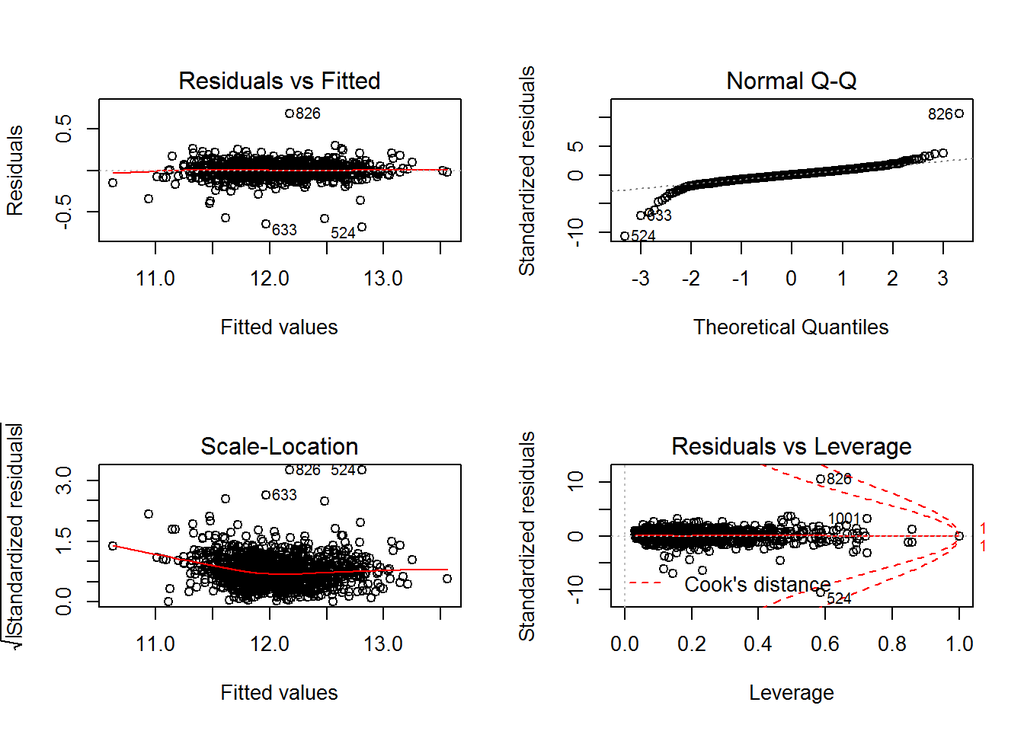

```r
par(mfrow=c(2,2))
plot(full_model_lm)
```

Viewing by 360 View:

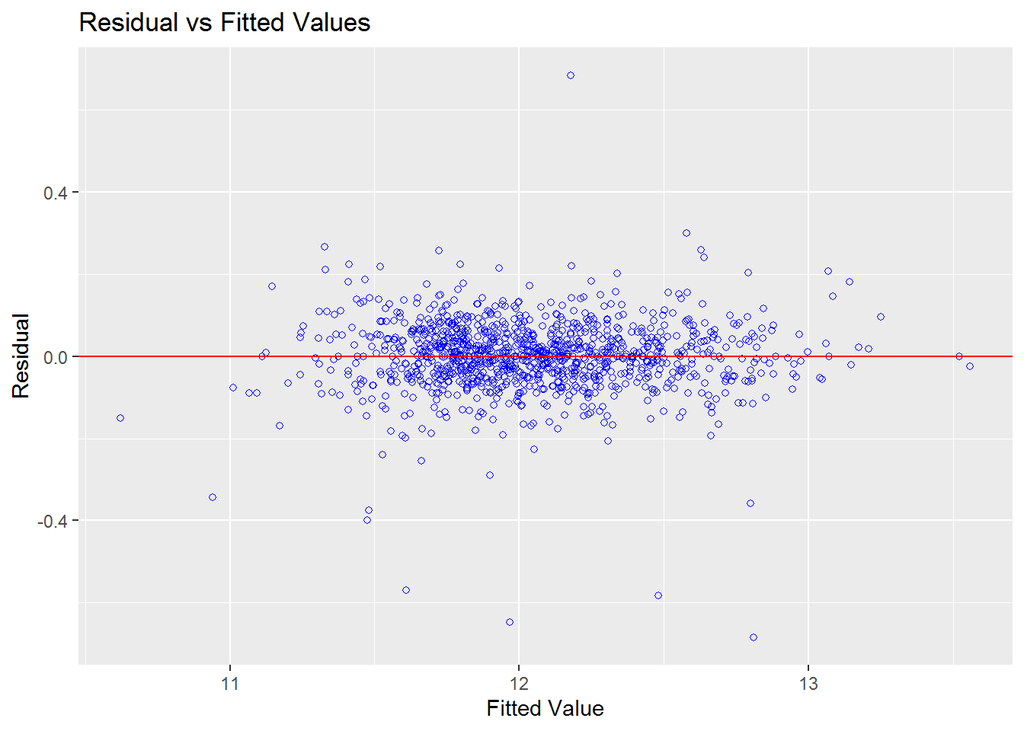

```r
ols_plot_resid_fit(full_model_lm)
```

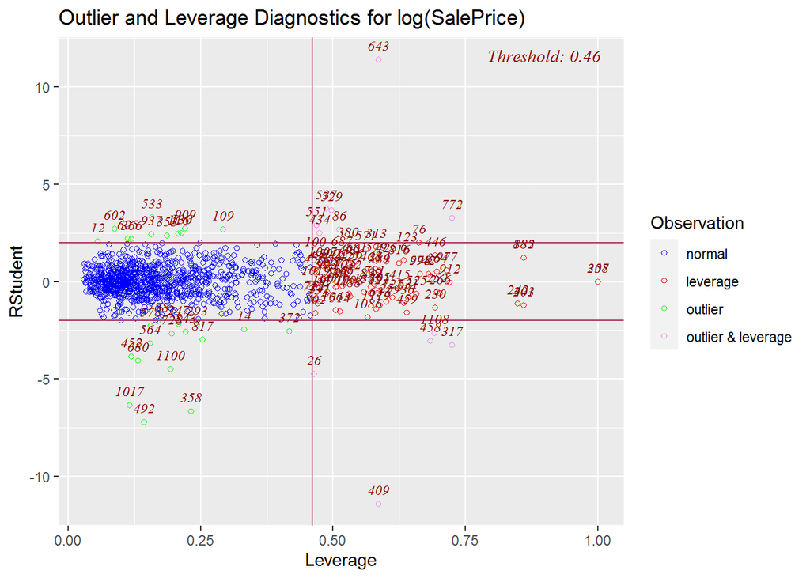

```r
ols_plot_resid_lev(full_model_lm)
```

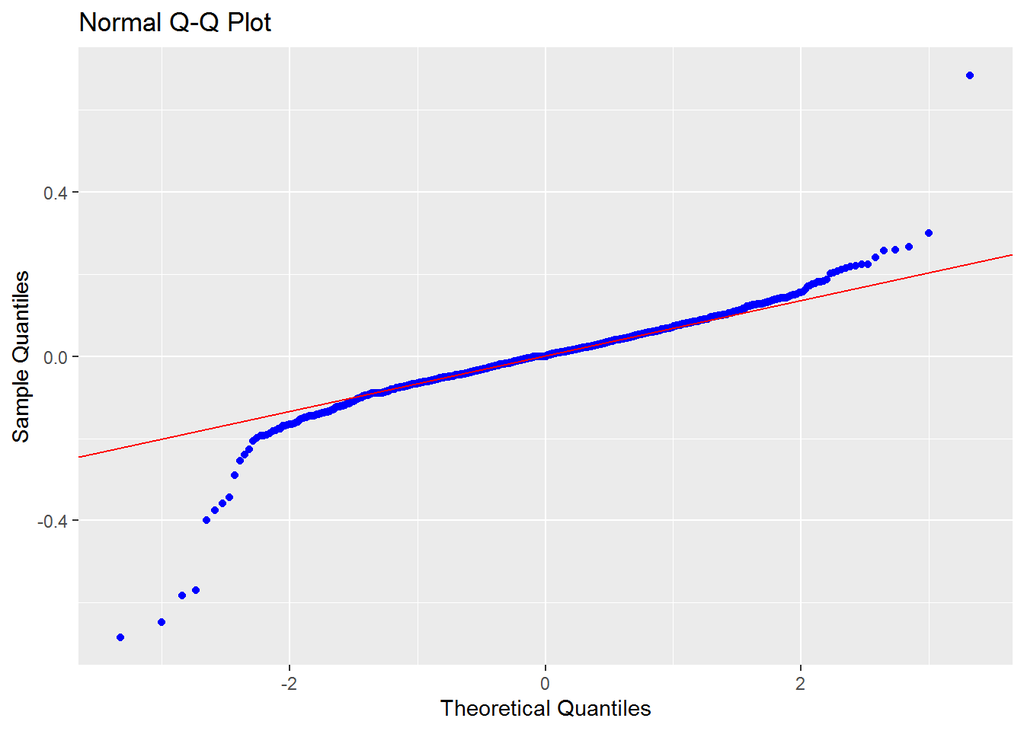

```r
ols_plot_resid_qq(full_model_lm)
```

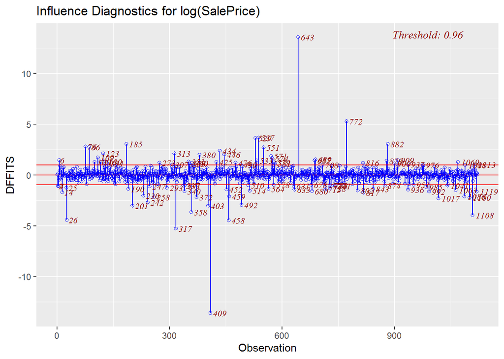

```r
ols_plot_dffits(full_model_lm)
```

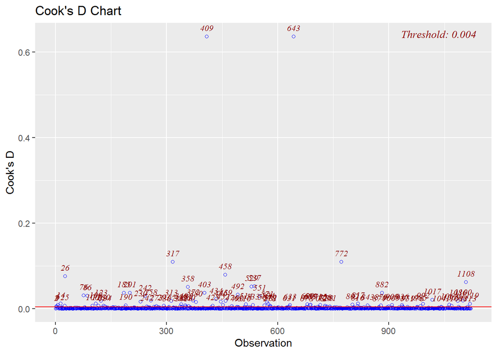

```r
ols_plot_cooksd_chart(full_model_lm)
```

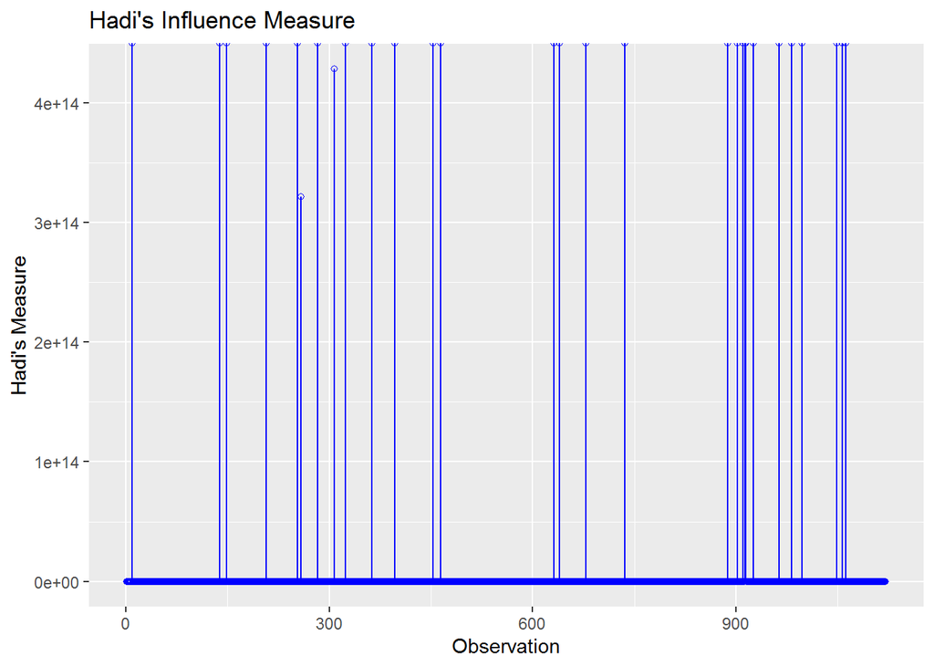

```r
ols_plot_hadi(full_model_lm)
```

We will make 5 Groups having 5 variables in each group to Idefiy only Significant Variables for our Final Model.

### 1) 1st Group :

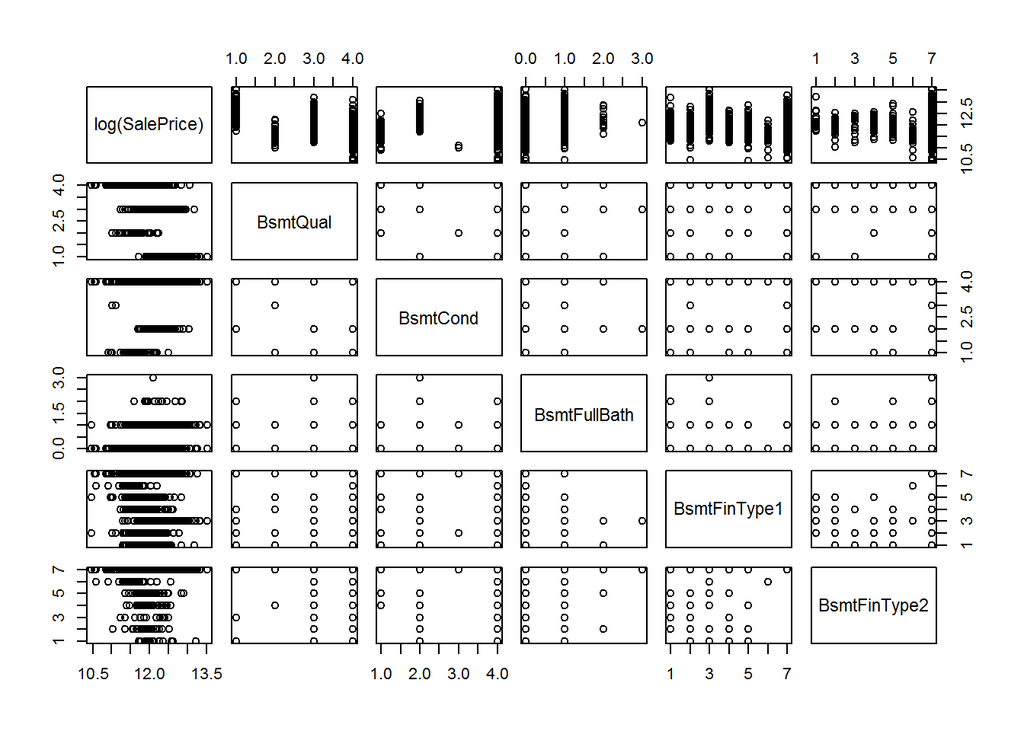

```r
group_basement <- as.formula(log(SalePrice) ~ BsmtQual+BsmtCond+BsmtFullBath+BsmtFinType1+BsmtFinType2)
pairs(group_basement, data = df_ames)
```

```r
lm_group_basement <- lm(group_basement, data = df_ames)
summary(lm_group_basement)
```

```
##
## Call:
## lm(formula = group_basement, data = df_ames)
##
## Residuals:
##      Min       1Q   Median       3Q      Max
## -1.34669 -0.15032 -0.00043  0.16503  1.29436
##
## Coefficients:
##                   Estimate Std. Error t value Pr(>|t|)
## (Intercept)     12.5818302  0.0939695 133.893  < 2e-16 ***
## BsmtQualFa      -0.8554624  0.0592846 -14.430  < 2e-16 ***
## BsmtQualGd      -0.4343751  0.0291331 -14.910  < 2e-16 ***
## BsmtQualTA      -0.7553053  0.0320425 -23.572  < 2e-16 ***
## BsmtCondGd       0.1901005  0.0583674   3.257 0.001152 **
## BsmtCondPo      -0.4923109  0.2135485  -2.305 0.021287 *
## BsmtCondTA       0.1384981  0.0455109   3.043 0.002383 **
## BsmtFullBath     0.0260950  0.0183908   1.419 0.156139
## BsmtFinType1BLQ -0.0168087  0.0312527  -0.538 0.590777
## BsmtFinType1GLQ  0.0964257  0.0269594   3.577 0.000359 ***
## BsmtFinType1LwQ -0.0279516  0.0414506  -0.674 0.500207
## BsmtFinType1Rec -0.0000856  0.0328024  -0.003 0.997918
## BsmtFinType1TA  -0.5835983  0.2940779  -1.985 0.047389 *
## BsmtFinType1Unf -0.0303091  0.0271780  -1.115 0.264947
## BsmtFinType2BLQ -0.1883999  0.0849273  -2.218 0.026685 *
## BsmtFinType2GLQ -0.2517440  0.1028662  -2.447 0.014512 *
## BsmtFinType2LwQ -0.1354861  0.0814742  -1.663 0.096543 .
## BsmtFinType2Rec -0.0818707  0.0792843  -1.033 0.301954
## BsmtFinType2TA   0.1482556  0.2971424   0.499 0.617899
## BsmtFinType2Unf -0.1580071  0.0697716  -2.265 0.023683 *
## ---
## Signif. codes:  0 '***' 0.001 '**' 0.01 '*' 0.05 '.' 0.1 ' ' 1
##
## Residual standard error: 0.2886 on 1440 degrees of freedom
## Multiple R-squared:  0.485,  Adjusted R-squared:  0.4782
## F-statistic: 71.36 on 19 and 1440 DF,  p-value: < 2.2e-16
```

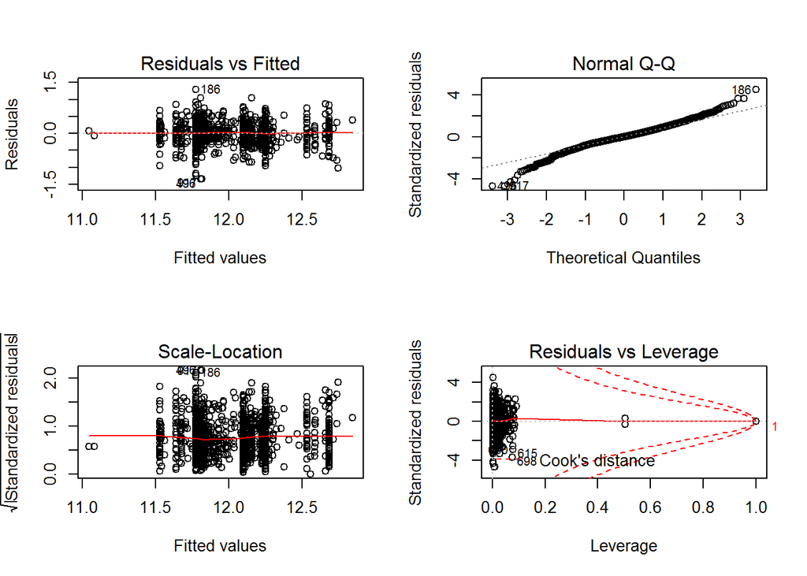

```r
par(mfrow = c(2, 2))
plot(lm_group_basement)
```

Analysis of Variance:

```r
aov(lm_group_basement)
```

```
## Call:
##    aov(formula = lm_group_basement)
##
## Terms:
##                  BsmtQual  BsmtCond BsmtFullBath BsmtFinType1 BsmtFinType2
## Sum of Squares  102.52857   1.88740      2.59823      4.89144      0.99122
## Deg. of Freedom         3         3            1            6            6
##                 Residuals
## Sum of Squares  119.90380
## Deg. of Freedom      1440
##
## Residual standard error: 0.2885594
## Estimated effects may be unbalanced
```

Detect MultiCollinearity

```r
vif(lm_group_basement)
```

```
##                    GVIF Df GVIF^(1/(2*Df))
## BsmtQual       1.788211  3        1.101716
## BsmtCond       1.189854  3        1.029396
## BsmtFullBath   1.595773  1        1.263239
## BsmtFinType1 107.527932  6        1.476704
## BsmtFinType2  51.918970  6        1.389773
```

We are removing BsmtFinType1 and BsmtFinType2 because Thes variable have high MultiCollinearity.

Model selection using AIC.

```r
AIC_lm_group_base <- stepAIC(lm_group_basement,direction = "backward",k=2, trace = 0, steps = 1000)
summary(AIC_lm_group_base)
```

```
##
## Call:
## lm(formula = log(SalePrice) ~ BsmtQual + BsmtCond + BsmtFullBath +
##     BsmtFinType1 + BsmtFinType2, data = df_ames)
##
## Residuals:
##      Min       1Q   Median       3Q      Max
## -1.34669 -0.15032 -0.00043  0.16503  1.29436
##
## Coefficients:
##                   Estimate Std. Error t value Pr(>|t|)
## (Intercept)     12.5818302  0.0939695 133.893  < 2e-16 ***
## BsmtQualFa      -0.8554624  0.0592846 -14.430  < 2e-16 ***
## BsmtQualGd      -0.4343751  0.0291331 -14.910  < 2e-16 ***
## BsmtQualTA      -0.7553053  0.0320425 -23.572  < 2e-16 ***
## BsmtCondGd       0.1901005  0.0583674   3.257 0.001152 **
## BsmtCondPo      -0.4923109  0.2135485  -2.305 0.021287 *
## BsmtCondTA       0.1384981  0.0455109   3.043 0.002383 **
## BsmtFullBath     0.0260950  0.0183908   1.419 0.156139
## BsmtFinType1BLQ -0.0168087  0.0312527  -0.538 0.590777
## BsmtFinType1GLQ  0.0964257  0.0269594   3.577 0.000359 ***
## BsmtFinType1LwQ -0.0279516  0.0414506  -0.674 0.500207
## BsmtFinType1Rec -0.0000856  0.0328024  -0.003 0.997918
## BsmtFinType1TA  -0.5835983  0.2940779  -1.985 0.047389 *
## BsmtFinType1Unf -0.0303091  0.0271780  -1.115 0.264947
## BsmtFinType2BLQ -0.1883999  0.0849273  -2.218 0.026685 *
## BsmtFinType2GLQ -0.2517440  0.1028662  -2.447 0.014512 *
## BsmtFinType2LwQ -0.1354861  0.0814742  -1.663 0.096543 .
## BsmtFinType2Rec -0.0818707  0.0792843  -1.033 0.301954
## BsmtFinType2TA   0.1482556  0.2971424   0.499 0.617899
## BsmtFinType2Unf -0.1580071  0.0697716  -2.265 0.023683 *
## ---
## Signif. codes:  0 '***' 0.001 '**' 0.01 '*' 0.05 '.' 0.1 ' ' 1
##
## Residual standard error: 0.2886 on 1440 degrees of freedom
## Multiple R-squared:  0.485,  Adjusted R-squared:  0.4782
## F-statistic: 71.36 on 19 and 1440 DF,  p-value: < 2.2e-16
```

We will chose Most Significant Variables from AIC_lm_group_base Model `(BsmtQual,BsmtCond)`.

### 2) 2nd Group :

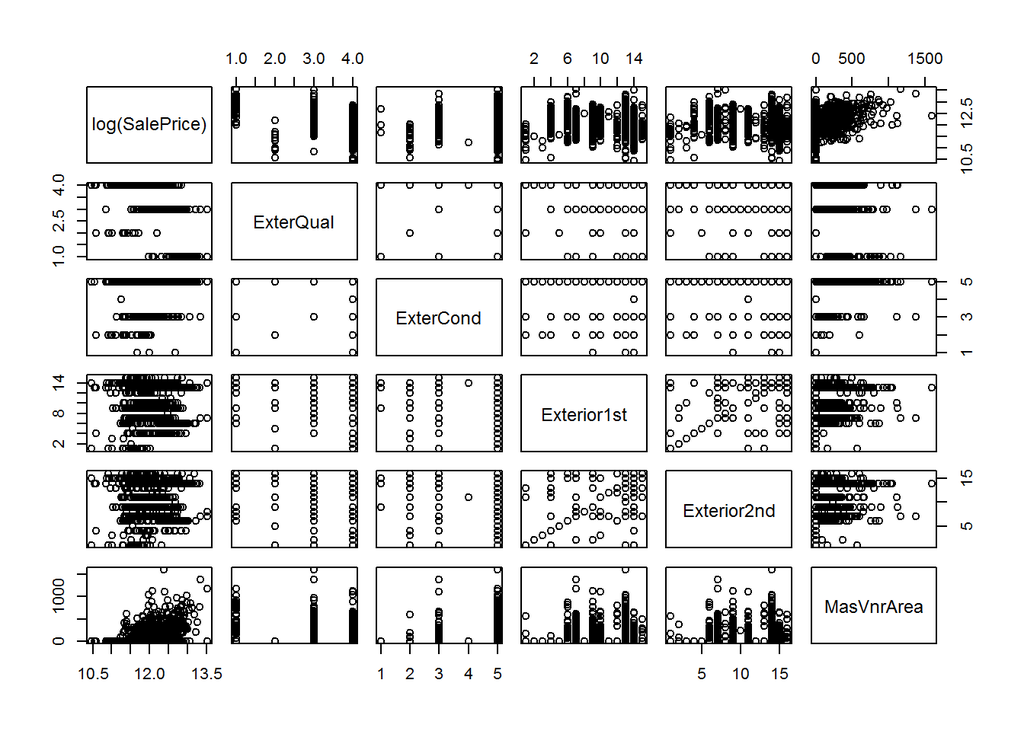

```r
group_Exter <-   as.formula(log(SalePrice) ~ ExterQual+ExterCond+Exterior1st+Exterior2nd+MasVnrArea)
pairs(group_Exter,data = df_ames)
```

```r
lm_group_Exter <-   lm(group_Exter, data = df_ames)
summary(lm_group_Exter)
```

```
##
## Call:
## lm(formula = group_Exter, data = df_ames)
##
## Residuals:
##     Min      1Q  Median      3Q     Max
## -1.3972 -0.1437  0.0005  0.1620  1.1986
##
## Coefficients: (1 not defined because of singularities)
##                      Estimate Std. Error t value Pr(>|t|)
## (Intercept)        12.3685626  0.1714006  72.162  < 2e-16 ***
## ExterQualFa        -1.1065146  0.0914677 -12.097  < 2e-16 ***
## ExterQualGd        -0.3293418  0.0434161  -7.586 5.96e-14 ***
## ExterQualTA        -0.7249536  0.0443157 -16.359  < 2e-16 ***
## ExterCondFa        -0.3481385  0.1662242  -2.094 0.036403 *
## ExterCondGd        -0.0829083  0.1582482  -0.524 0.600421
## ExterCondPo        -0.7282405  0.3167127  -2.299 0.021629 *
## ExterCondTA        -0.0889929  0.1568976  -0.567 0.570666
## Exterior1stAsphShn  0.0822216  0.3546691   0.232 0.816706
## Exterior1stBrkComm -0.2647032  0.2588906  -1.022 0.306742
## Exterior1stBrkFace  0.5473767  0.1252971   4.369 1.34e-05 ***
## Exterior1stCBlock   0.3886605  0.2874850   1.352 0.176613
## Exterior1stCemntBd  0.4266920  0.1975350   2.160 0.030934 *
## Exterior1stHdBoard  0.2137223  0.1249305   1.711 0.087350 .
## Exterior1stImStucc  0.4587907  0.3082835   1.488 0.136918
## Exterior1stMetalSd  0.2245808  0.1469444   1.528 0.126652
## Exterior1stPlywood  0.3589189  0.1227729   2.923 0.003517 **
## Exterior1stStone    0.8275547  0.2365595   3.498 0.000483 ***
## Exterior1stStucco   0.3359540  0.1421082   2.364 0.018210 *
## Exterior1stVinylSd  0.2394488  0.1327581   1.804 0.071499 .
## Exterior1stWd Sdng  0.3052450  0.1217199   2.508 0.012261 *
## Exterior1stWdShing  0.2105964  0.1316260   1.600 0.109831
## Exterior2ndAsphShn -0.1239124  0.2305186  -0.538 0.590981
## Exterior2ndBrk Cmn -0.0020530  0.1732080  -0.012 0.990545
## Exterior2ndBrkFace -0.1429571  0.1357777  -1.053 0.292577
## Exterior2ndCBlock          NA         NA      NA       NA
## Exterior2ndCmentBd -0.1681721  0.1993714  -0.844 0.399085
## Exterior2ndHdBoard  0.0515450  0.1262415   0.408 0.683112
## Exterior2ndImStucc  0.0670812  0.1487124   0.451 0.652001
## Exterior2ndMetalSd -0.0409977  0.1482200  -0.277 0.782127
## Exterior2ndOther    0.3664271  0.3007495   1.218 0.223283
## Exterior2ndPlywood  0.0244325  0.1214786   0.201 0.840629
## Exterior2ndStone   -0.2984264  0.1881623  -1.586 0.112961
## Exterior2ndStucco  -0.1160056  0.1394649  -0.832 0.405667
## Exterior2ndVinylSd  0.0665347  0.1326293   0.502 0.615986
## Exterior2ndWd Sdng -0.0914123  0.1223140  -0.747 0.454972
## Exterior2ndWd Shng -0.0614781  0.1276576  -0.482 0.630174
## MasVnrArea          0.0004909  0.0000437  11.234  < 2e-16 ***
## ---
## Signif. codes:  0 '***' 0.001 '**' 0.01 '*' 0.05 '.' 0.1 ' ' 1
##
## Residual standard error: 0.2699 on 1415 degrees of freedom
##   (8 observations deleted due to missingness)
## Multiple R-squared:  0.5545, Adjusted R-squared:  0.5432
## F-statistic: 48.93 on 36 and 1415 DF,  p-value: < 2.2e-16
```

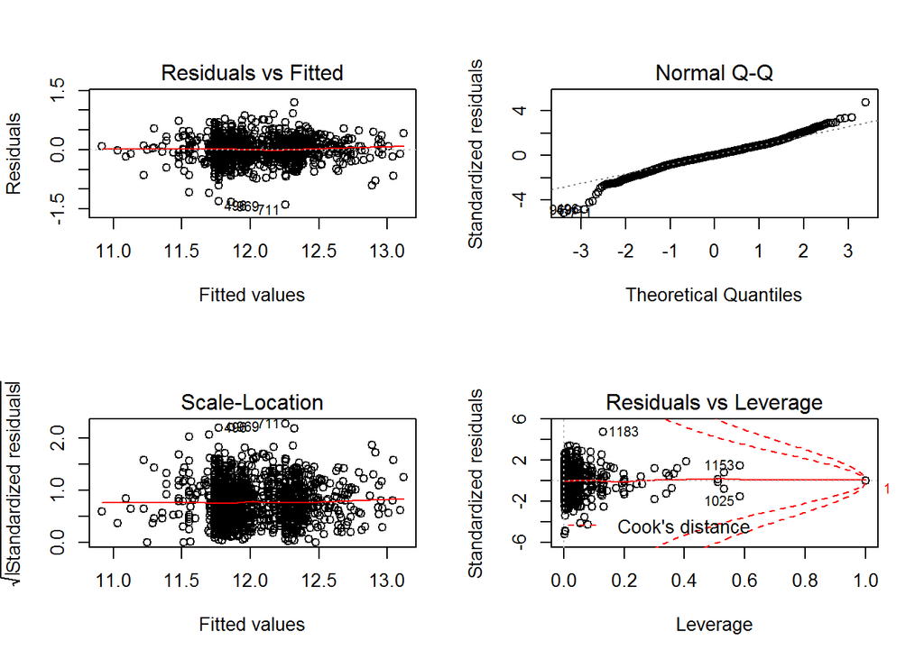

```r
par(mfrow = c(2, 2))
plot(lm_group_Exter)
```

Analysis of Variance:

```r
aov(lm_group_Exter)
```

```
## Call:
##    aov(formula = lm_group_Exter)
##
## Terms:
##                 ExterQual ExterCond Exterior1st Exterior2nd MasVnrArea
## Sum of Squares  106.16087   2.64269     8.75628     1.57945    9.19382
## Deg. of Freedom         3         4          14          14          1
##                 Residuals
## Sum of Squares  103.08909
## Deg. of Freedom      1415
##
## Residual standard error: 0.2699157
## 1 out of 38 effects not estimable
## Estimated effects may be unbalanced
## 8 observations deleted due to missingness
```

Detect MultiCollinearity

```r
attributes(alias(lm_group_Exter)$Complete)$dimnames[[1]]
```

```
## [1] "Exterior2ndCBlock"
```

Model selection using AIC:

```r
AIC_lm_group_Exter <- stepAIC(lm_group_Exter,direction = "backward",k=2, trace = 0, steps = 1000)
summary(AIC_lm_group_Exter)
```

```
##
## Call:
## lm(formula = log(SalePrice) ~ ExterQual + ExterCond + Exterior1st +
##     MasVnrArea, data = df_ames)
##
## Residuals:
##     Min      1Q  Median      3Q     Max
## -1.3949 -0.1447  0.0000  0.1641  1.3453
##
## Coefficients:
##                      Estimate Std. Error t value Pr(>|t|)
## (Intercept)        12.3625288  0.1704966  72.509  < 2e-16 ***
## ExterQualFa        -1.1127931  0.0908965 -12.242  < 2e-16 ***
## ExterQualGd        -0.3258570  0.0432905  -7.527 9.13e-14 ***
## ExterQualTA        -0.7237661  0.0441410 -16.397  < 2e-16 ***
## ExterCondFa        -0.3403658  0.1662230  -2.048 0.040777 *
## ExterCondGd        -0.0772929  0.1583149  -0.488 0.625467
## ExterCondPo        -0.6213628  0.3125036  -1.988 0.046965 *
## ExterCondTA        -0.0884328  0.1569657  -0.563 0.573258
## Exterior1stAsphShn -0.0374044  0.2768093  -0.135 0.892530
## Exterior1stBrkComm -0.2660762  0.2016990  -1.319 0.187322
## Exterior1stBrkFace  0.4503781  0.0717290   6.279 4.51e-10 ***
## Exterior1stCBlock   0.4004128  0.2873762   1.393 0.163734
## Exterior1stCemntBd  0.2637977  0.0712457   3.703 0.000221 ***
## Exterior1stHdBoard  0.2624537  0.0634101   4.139 3.69e-05 ***
## Exterior1stImStucc  0.5278608  0.2773708   1.903 0.057230 .
## Exterior1stMetalSd  0.1858244  0.0633986   2.931 0.003432 **
## Exterior1stPlywood  0.3840173  0.0660438   5.815 7.49e-09 ***
## Exterior1stStone    0.7072516  0.2005742   3.526 0.000435 ***
## Exterior1stStucco   0.2180409  0.0814560   2.677 0.007518 **
## Exterior1stVinylSd  0.3056553  0.0628056   4.867 1.26e-06 ***
## Exterior1stWd Sdng  0.2276462  0.0634409   3.588 0.000344 ***
## Exterior1stWdShing  0.1741323  0.0805837   2.161 0.030870 *
## MasVnrArea          0.0004999  0.0000435  11.493  < 2e-16 ***
## ---
## Signif. codes:  0 '***' 0.001 '**' 0.01 '*' 0.05 '.' 0.1 ' ' 1
##
## Residual standard error: 0.2701 on 1429 degrees of freedom
##   (8 observations deleted due to missingness)
## Multiple R-squared:  0.5496, Adjusted R-squared:  0.5427
## F-statistic: 79.27 on 22 and 1429 DF,  p-value: < 2.2e-16
```

We will chose Most Significant Variables from AIC_lm_group_Exter Model `(ExterQual,MasVnrArea)`

### 3) 3rd Group :

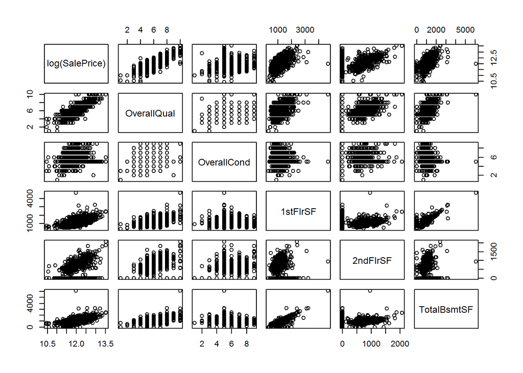

```r
group_OverAll    <-   as.formula("log(SalePrice) ~ OverallQual+OverallCond+`1stFlrSF`+`2ndFlrSF`+TotalBsmtSF")
pairs(group_OverAll, data = df_ames)
```

```r
lm_group_OverAll <-  lm(group_OverAll, data = df_ames)
summary(lm_group_OverAll)
```

```
##
## Call:
## lm(formula = group_OverAll, data = df_ames)
##
## Residuals:
##      Min       1Q   Median       3Q      Max
## -2.45801 -0.07819  0.02140  0.11169  0.63834
##
## Coefficients:
##              Estimate Std. Error t value Pr(>|t|)
## (Intercept) 1.038e+01  3.651e-02 284.176  < 2e-16 ***
## OverallQual 1.565e-01  4.905e-03  31.909  < 2e-16 ***
## OverallCond 2.557e-02  4.562e-03   5.605 2.49e-08 ***
## `1stFlrSF`  2.852e-04  2.293e-05  12.437  < 2e-16 ***
## `2ndFlrSF`  2.187e-04  1.334e-05  16.386  < 2e-16 ***
## TotalBsmtSF 1.351e-04  2.121e-05   6.371 2.52e-10 ***
## ---
## Signif. codes:  0 '***' 0.001 '**' 0.01 '*' 0.05 '.' 0.1 ' ' 1
##
## Residual standard error: 0.191 on 1454 degrees of freedom
## Multiple R-squared:  0.7721, Adjusted R-squared:  0.7713
## F-statistic: 985.1 on 5 and 1454 DF,  p-value: < 2.2e-16
```

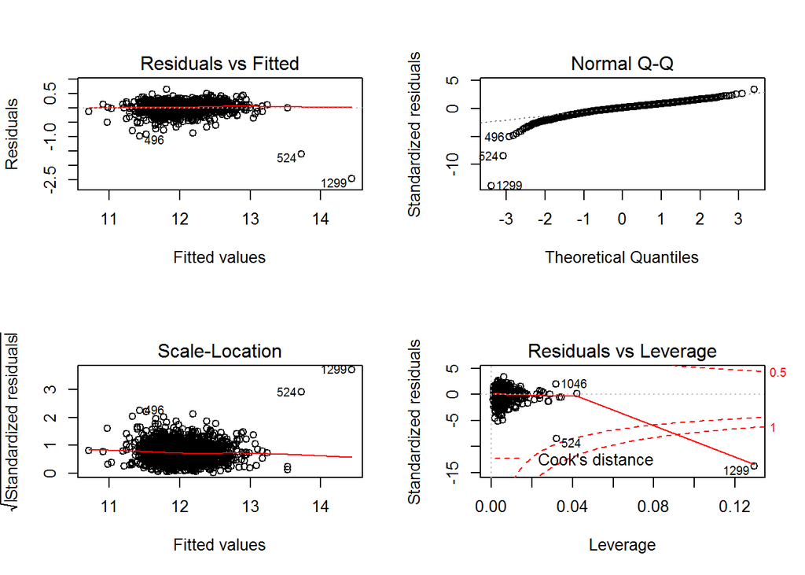

```r
par(mfrow = c(2, 2))
plot(lm_group_OverAll)
```

Analysis of Variance:

```r
aov(lm_group_OverAll)
```

```
## Call:
##    aov(formula = lm_group_OverAll)
##
## Terms:
##                 OverallQual OverallCond `1stFlrSF` `2ndFlrSF` TotalBsmtSF
## Sum of Squares    155.46204     0.34364   13.67256    8.78401     1.48098
## Deg. of Freedom           1           1          1          1           1
##                 Residuals
## Sum of Squares   53.05743
## Deg. of Freedom      1454
##
## Residual standard error: 0.1910253
## Estimated effects may be unbalanced
```

Detect MultiCollinearity:

```r
vif(lm_group_OverAll)
```

```
## OverallQual OverallCond  `1stFlrSF`  `2ndFlrSF` TotalBsmtSF
##    1.839809    1.030214    3.141513    1.356624    3.462239
```

Model selection using AIC:

```r
AIC_lm_group_OverAll <- stepAIC(lm_group_OverAll,direction = "backward",k=2, trace = 0, steps = 1000)
summary(AIC_lm_group_OverAll)
```

```
##
## Call:
## lm(formula = log(SalePrice) ~ OverallQual + OverallCond + `1stFlrSF` +
##     `2ndFlrSF` + TotalBsmtSF, data = df_ames)
##
## Residuals:
##      Min       1Q   Median       3Q      Max
## -2.45801 -0.07819  0.02140  0.11169  0.63834
##
## Coefficients:
##              Estimate Std. Error t value Pr(>|t|)
## (Intercept) 1.038e+01  3.651e-02 284.176  < 2e-16 ***
## OverallQual 1.565e-01  4.905e-03  31.909  < 2e-16 ***
## OverallCond 2.557e-02  4.562e-03   5.605 2.49e-08 ***
## `1stFlrSF`  2.852e-04  2.293e-05  12.437  < 2e-16 ***
## `2ndFlrSF`  2.187e-04  1.334e-05  16.386  < 2e-16 ***
## TotalBsmtSF 1.351e-04  2.121e-05   6.371 2.52e-10 ***
## ---
## Signif. codes:  0 '***' 0.001 '**' 0.01 '*' 0.05 '.' 0.1 ' ' 1
##
## Residual standard error: 0.191 on 1454 degrees of freedom
## Multiple R-squared:  0.7721, Adjusted R-squared:  0.7713
## F-statistic: 985.1 on 5 and 1454 DF,  p-value: < 2.2e-16
```

We will chose All Significant Variables from AIC_lm_group_OverAll `(OverallQual,OverallCond,`1stFlrSF`,`2ndFlrSF`,TotalBsmtSF)`.

### 4) 4th Group :

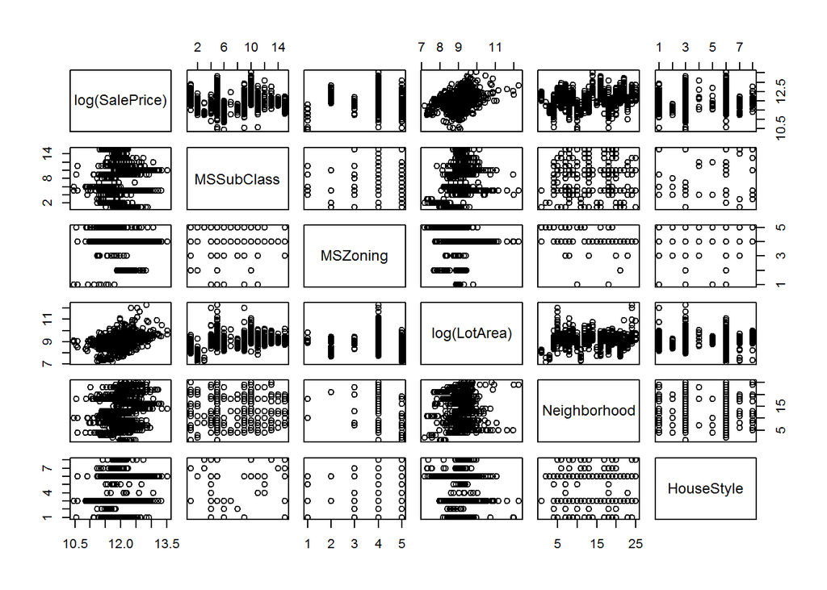

```r
group_Others    <-   as.formula(log(SalePrice) ~ MSSubClass+MSZoning+log(LotArea)+Neighborhood+HouseStyle)
pairs(group_Others,data = df_ames)
```

```r
lm_group_Others <-  lm(group_Others, data = df_ames)
summary(lm_group_Others)
```

```
##
## Call:
## lm(formula = group_Others, data = df_ames)
##
## Residuals:
##      Min       1Q   Median       3Q      Max
## -1.15088 -0.12395 -0.00131  0.12448  0.81812
##
## Coefficients:
##                      Estimate Std. Error t value Pr(>|t|)
## (Intercept)          9.729848   0.196839  49.430  < 2e-16 ***
## MSSubClass160       -0.114275   0.077489  -1.475 0.140510
## MSSubClass180       -0.052267   0.112396  -0.465 0.641984
## MSSubClass190       -0.254203   0.071252  -3.568 0.000372 ***
## MSSubClass20         0.008543   0.034854   0.245 0.806403
## MSSubClass30        -0.324958   0.048471  -6.704 2.92e-11 ***
## MSSubClass40        -0.072644   0.117758  -0.617 0.537403
## MSSubClass45        -0.411583   0.177962  -2.313 0.020879 *
## MSSubClass50        -0.163822   0.080711  -2.030 0.042573 *
## MSSubClass60         0.011114   0.071199   0.156 0.875982
## MSSubClass70        -0.117140   0.076543  -1.530 0.126146
## MSSubClass75        -0.142620   0.130987  -1.089 0.276422
## MSSubClass80        -0.054460   0.108015  -0.504 0.614208
## MSSubClass85        -0.115643   0.095021  -1.217 0.223799
## MSSubClass90        -0.145511   0.050635  -2.874 0.004118 **
## MSZoningFV           0.399896   0.104377   3.831 0.000133 ***
## MSZoningRH           0.370687   0.105472   3.515 0.000454 ***
## MSZoningRL           0.476721   0.087385   5.455 5.76e-08 ***
## MSZoningRM           0.566486   0.081445   6.955 5.36e-12 ***
## log(LotArea)         0.256814   0.018516  13.870  < 2e-16 ***
## NeighborhoodBlueste -0.255248   0.176106  -1.449 0.147450
## NeighborhoodBrDale  -0.564307   0.096219  -5.865 5.59e-09 ***
## NeighborhoodBrkSide -0.599931   0.075874  -7.907 5.29e-15 ***
## NeighborhoodClearCr -0.418471   0.077336  -5.411 7.35e-08 ***
## NeighborhoodCollgCr -0.323968   0.064087  -5.055 4.87e-07 ***
## NeighborhoodCrawfor -0.230271   0.071584  -3.217 0.001326 **
## NeighborhoodEdwards -0.665768   0.066902  -9.951  < 2e-16 ***
## NeighborhoodGilbert -0.418510   0.067657  -6.186 8.08e-10 ***
## NeighborhoodIDOTRR  -0.760143   0.087621  -8.675  < 2e-16 ***
## NeighborhoodMeadowV -0.702544   0.095502  -7.356 3.20e-13 ***
```

[output cut: 12 more lines]

```
## NeighborhoodTimber  -0.227246   0.073316  -3.100 0.001977 **
## NeighborhoodVeenker -0.203045   0.090640  -2.240 0.025238 *
## HouseStyle1.5Unf     0.062542   0.172042   0.364 0.716263
## HouseStyle1Story    -0.129697   0.070359  -1.843 0.065485 .
## HouseStyle2.5Fin     0.260033   0.132267   1.966 0.049498 *
## HouseStyle2.5Unf     0.139180   0.129738   1.073 0.283556
## HouseStyle2Story     0.006277   0.067557   0.093 0.925989
## HouseStyleSFoyer    -0.010265   0.093259  -0.110 0.912370
## HouseStyleSLvl      -0.017741   0.111261  -0.159 0.873335
## ---
## Signif. codes:  0 '***' 0.001 '**' 0.01 '*' 0.05 '.' 0.1 ' ' 1
##
## Residual standard error: 0.223 on 1409 degrees of freedom
## Multiple R-squared:  0.6991, Adjusted R-squared:  0.6884
## F-statistic: 65.48 on 50 and 1409 DF,  p-value: < 2.2e-16
```

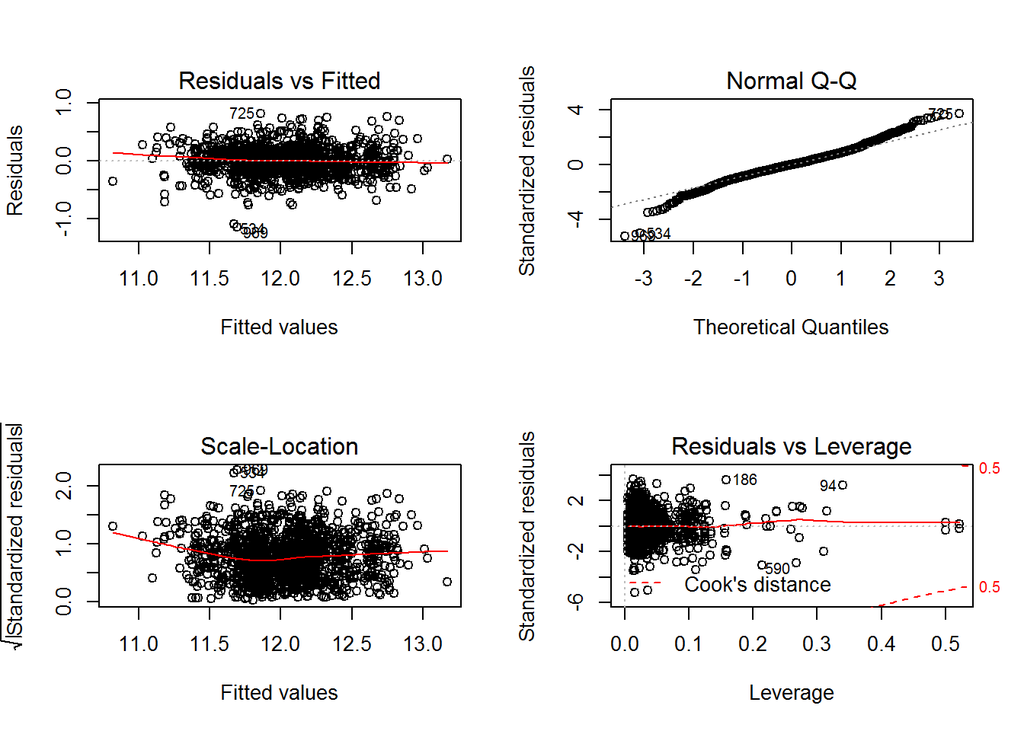

```r
par(mfrow = c(2, 2))
plot(lm_group_Others)
```

Analysis of Variance:

```r
aov(lm_group_Others)
```

```
## Call:
##    aov(formula = lm_group_Others)
##
## Terms:
##                 MSSubClass MSZoning log(LotArea) Neighborhood HouseStyle
## Sum of Squares    76.85381 12.11975     21.72664     51.42495    0.63048
## Deg. of Freedom         14        4            1           24          7
##                 Residuals
## Sum of Squares   70.04503
## Deg. of Freedom      1409
##
## Residual standard error: 0.2229632
## Estimated effects may be unbalanced
```

Detect MultiCollinearity:

```r
vif(lm_group_Others)
```

```
##                      GVIF Df GVIF^(1/(2*Df))
## MSSubClass   4.213519e+06 14        1.724227
## MSZoning     2.584326e+01  4        1.501563
## log(LotArea) 2.694110e+00  1        1.641374
## Neighborhood 3.827856e+02 24        1.131909
## HouseStyle   2.898825e+05  7        2.455606
```

Model selection using AIC:

```r
AIC_lm_group_Others <- stepAIC(lm_group_Others,direction = "backward",k=2, trace = 0, steps = 1000)
summary(lm_group_Others)
```

```
##
## Call:
## lm(formula = group_Others, data = df_ames)
##
## Residuals:
##      Min       1Q   Median       3Q      Max
## -1.15088 -0.12395 -0.00131  0.12448  0.81812
##
## Coefficients:
##                      Estimate Std. Error t value Pr(>|t|)
## (Intercept)          9.729848   0.196839  49.430  < 2e-16 ***
## MSSubClass160       -0.114275   0.077489  -1.475 0.140510
## MSSubClass180       -0.052267   0.112396  -0.465 0.641984
## MSSubClass190       -0.254203   0.071252  -3.568 0.000372 ***
## MSSubClass20         0.008543   0.034854   0.245 0.806403
## MSSubClass30        -0.324958   0.048471  -6.704 2.92e-11 ***
## MSSubClass40        -0.072644   0.117758  -0.617 0.537403
## MSSubClass45        -0.411583   0.177962  -2.313 0.020879 *
## MSSubClass50        -0.163822   0.080711  -2.030 0.042573 *
## MSSubClass60         0.011114   0.071199   0.156 0.875982
## MSSubClass70        -0.117140   0.076543  -1.530 0.126146
## MSSubClass75        -0.142620   0.130987  -1.089 0.276422
## MSSubClass80        -0.054460   0.108015  -0.504 0.614208
## MSSubClass85        -0.115643   0.095021  -1.217 0.223799
## MSSubClass90        -0.145511   0.050635  -2.874 0.004118 **
## MSZoningFV           0.399896   0.104377   3.831 0.000133 ***
## MSZoningRH           0.370687   0.105472   3.515 0.000454 ***
## MSZoningRL           0.476721   0.087385   5.455 5.76e-08 ***
## MSZoningRM           0.566486   0.081445   6.955 5.36e-12 ***
## log(LotArea)         0.256814   0.018516  13.870  < 2e-16 ***
## NeighborhoodBlueste -0.255248   0.176106  -1.449 0.147450
## NeighborhoodBrDale  -0.564307   0.096219  -5.865 5.59e-09 ***
## NeighborhoodBrkSide -0.599931   0.075874  -7.907 5.29e-15 ***
## NeighborhoodClearCr -0.418471   0.077336  -5.411 7.35e-08 ***
## NeighborhoodCollgCr -0.323968   0.064087  -5.055 4.87e-07 ***
## NeighborhoodCrawfor -0.230271   0.071584  -3.217 0.001326 **
## NeighborhoodEdwards -0.665768   0.066902  -9.951  < 2e-16 ***
## NeighborhoodGilbert -0.418510   0.067657  -6.186 8.08e-10 ***
## NeighborhoodIDOTRR  -0.760143   0.087621  -8.675  < 2e-16 ***
## NeighborhoodMeadowV -0.702544   0.095502  -7.356 3.20e-13 ***
```

[output cut: 12 more lines]

```
## NeighborhoodTimber  -0.227246   0.073316  -3.100 0.001977 **
## NeighborhoodVeenker -0.203045   0.090640  -2.240 0.025238 *
## HouseStyle1.5Unf     0.062542   0.172042   0.364 0.716263
## HouseStyle1Story    -0.129697   0.070359  -1.843 0.065485 .
## HouseStyle2.5Fin     0.260033   0.132267   1.966 0.049498 *
## HouseStyle2.5Unf     0.139180   0.129738   1.073 0.283556
## HouseStyle2Story     0.006277   0.067557   0.093 0.925989
## HouseStyleSFoyer    -0.010265   0.093259  -0.110 0.912370
## HouseStyleSLvl      -0.017741   0.111261  -0.159 0.873335
## ---
## Signif. codes:  0 '***' 0.001 '**' 0.01 '*' 0.05 '.' 0.1 ' ' 1
##
## Residual standard error: 0.223 on 1409 degrees of freedom
## Multiple R-squared:  0.6991, Adjusted R-squared:  0.6884
## F-statistic: 65.48 on 50 and 1409 DF,  p-value: < 2.2e-16
```

### 5) 5th Group :

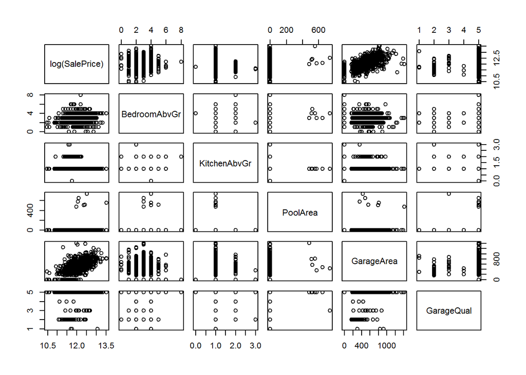

```r
group_Garage1  <-    as.formula(log(SalePrice) ~ BedroomAbvGr+KitchenAbvGr+PoolArea+GarageArea+GarageQual)
pairs(group_Garage1, data = df_ames)
```

```r
lm_group_Garage1 <-  lm(group_Garage1, data = df_ames)
summary(lm_group_Garage1)
```

```
##
## Call:
## lm(formula = group_Garage1, data = df_ames)
##
## Residuals:
##      Min       1Q   Median       3Q      Max
## -1.54960 -0.15035  0.00894  0.16114  1.03978
##
## Coefficients:
##                Estimate Std. Error t value Pr(>|t|)
## (Intercept)   1.138e+01  1.734e-01  65.635  < 2e-16 ***
## BedroomAbvGr  9.551e-02  9.538e-03  10.013  < 2e-16 ***
## KitchenAbvGr -2.567e-01  3.538e-02  -7.254 6.56e-13 ***
## PoolArea      1.161e-04  1.908e-04   0.608    0.543
## GarageArea    1.154e-03  3.607e-05  32.002  < 2e-16 ***
## GarageQualFa -4.772e-02  1.728e-01  -0.276    0.782
## GarageQualGd  2.148e-01  1.845e-01   1.164    0.244
## GarageQualPo -1.996e-01  2.369e-01  -0.842    0.400
## GarageQualTA  9.363e-02  1.674e-01   0.559    0.576
## ---
## Signif. codes:  0 '***' 0.001 '**' 0.01 '*' 0.05 '.' 0.1 ' ' 1
##
## Residual standard error: 0.2894 on 1451 degrees of freedom
## Multiple R-squared:  0.4781, Adjusted R-squared:  0.4752
## F-statistic: 166.2 on 8 and 1451 DF,  p-value: < 2.2e-16
```

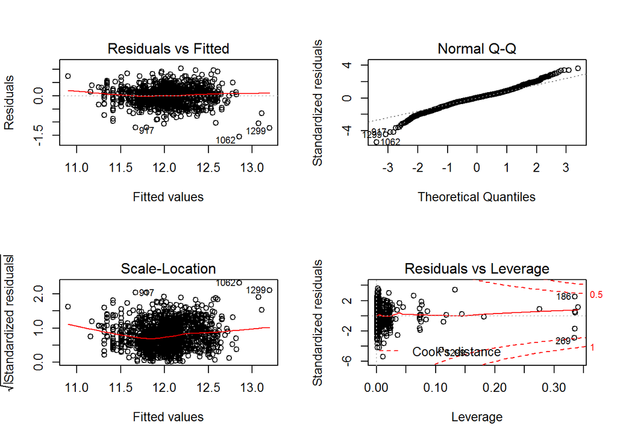

```r
par(mfrow = c(2, 2))
plot(lm_group_Garage1)
```

Analysis of Variance:

```r
aov(lm_group_Garage1)
```

```
## Call:
##    aov(formula = lm_group_Garage1)
##
## Terms:
##                 BedroomAbvGr KitchenAbvGr  PoolArea GarageArea GarageQual
## Sum of Squares      10.17322      8.66314   0.57135   90.51023    1.38891
## Deg. of Freedom            1            1         1          1          4
##                 Residuals
## Sum of Squares  121.49381
## Deg. of Freedom      1451
##
## Residual standard error: 0.2893632
## Estimated effects may be unbalanced
```

Detect MultiCollinearity:

```r
vif(lm_group_Garage1)
```

```
##                  GVIF Df GVIF^(1/(2*Df))
## BedroomAbvGr 1.054916  1        1.027091
## KitchenAbvGr 1.058976  1        1.029066
## PoolArea     1.024370  1        1.012112
## GarageArea   1.036278  1        1.017977
## GarageQual   1.050802  4        1.006213
```

Model selection using AIC:

```r
AIC_lm_group_Garage <- stepAIC(lm_group_Garage1,direction = "backward",k=2, trace = 0, steps = 1000)
summary(AIC_lm_group_Garage)
```

```
##
## Call:
## lm(formula = log(SalePrice) ~ BedroomAbvGr + KitchenAbvGr + GarageArea +
##     GarageQual, data = df_ames)
##
## Residuals:
##      Min       1Q   Median       3Q      Max
## -1.55037 -0.15109  0.00855  0.16082  1.03964
##
## Coefficients:
##                Estimate Std. Error t value Pr(>|t|)
## (Intercept)   1.138e+01  1.734e-01  65.647  < 2e-16 ***
## BedroomAbvGr  9.594e-02  9.510e-03  10.088  < 2e-16 ***
## KitchenAbvGr -2.573e-01  3.536e-02  -7.278 5.52e-13 ***
## GarageArea    1.155e-03  3.602e-05  32.078  < 2e-16 ***
## GarageQualFa -4.729e-02  1.727e-01  -0.274    0.784
## GarageQualGd  2.211e-01  1.842e-01   1.201    0.230
## GarageQualPo -1.989e-01  2.368e-01  -0.840    0.401
## GarageQualTA  9.407e-02  1.674e-01   0.562    0.574
## ---
## Signif. codes:  0 '***' 0.001 '**' 0.01 '*' 0.05 '.' 0.1 ' ' 1
##
## Residual standard error: 0.2893 on 1452 degrees of freedom
## Multiple R-squared:  0.478,  Adjusted R-squared:  0.4755
## F-statistic: 189.9 on 7 and 1452 DF,  p-value: < 2.2e-16
```

We will chose All Significant Variables from AIC_lm_group_Garage `(BedroomAbvGr+KitchenAbvGr+GarageArea)`.

# Final Model:

```r
group_final <-  as.formula("log(SalePrice) ~ BsmtQual+BsmtCond+ExterQual+MasVnrArea+log(LotArea)+MSZoning+OverallQual+OverallCond+`1stFlrSF`+`2ndFlrSF`+TotalBsmtSF+BedroomAbvGr+KitchenAbvGr+GarageArea")
final_model <- lm(group_final, data = df_ames)
summary(final_model)
```

```
##
## Call:
## lm(formula = group_final, data = df_ames)
##
## Residuals:
##      Min       1Q   Median       3Q      Max
## -2.23415 -0.06770  0.00947  0.08243  0.60669
##
## Coefficients:
##                Estimate Std. Error t value Pr(>|t|)
## (Intercept)   9.760e+00  1.133e-01  86.144  < 2e-16 ***
## BsmtQualFa   -2.665e-01  3.528e-02  -7.553 7.57e-14 ***
## BsmtQualGd   -1.009e-01  1.889e-02  -5.340 1.08e-07 ***
## BsmtQualTA   -2.021e-01  2.200e-02  -9.186  < 2e-16 ***
## BsmtCondGd    7.481e-02  3.150e-02   2.375 0.017667 *
## BsmtCondPo   -5.031e-02  1.162e-01  -0.433 0.665206
## BsmtCondTA    6.976e-02  2.456e-02   2.841 0.004562 **
## ExterQualFa  -7.538e-02  5.454e-02  -1.382 0.167159
## ExterQualGd   2.800e-02  2.697e-02   1.038 0.299285
## ExterQualTA  -4.352e-02  2.965e-02  -1.468 0.142413
## MasVnrArea    5.761e-05  2.629e-05   2.192 0.028568 *
## log(LotArea)  7.674e-02  1.017e-02   7.545 8.02e-14 ***
## MSZoningFV    5.039e-01  5.535e-02   9.105  < 2e-16 ***
## MSZoningRH    4.327e-01  6.333e-02   6.832 1.23e-11 ***
## MSZoningRL    4.695e-01  5.132e-02   9.148  < 2e-16 ***
## MSZoningRM    3.515e-01  5.205e-02   6.752 2.11e-11 ***
## OverallQual   8.577e-02  5.423e-03  15.816  < 2e-16 ***
## OverallCond   4.224e-02  4.049e-03  10.434  < 2e-16 ***
## `1stFlrSF`    2.207e-04  2.125e-05  10.384  < 2e-16 ***
## `2ndFlrSF`    1.996e-04  1.409e-05  14.171  < 2e-16 ***
## TotalBsmtSF   7.359e-05  1.750e-05   4.206 2.77e-05 ***
## BedroomAbvGr  5.749e-04  6.600e-03   0.087 0.930593
## KitchenAbvGr -7.412e-02  2.018e-02  -3.673 0.000248 ***
## GarageArea    2.478e-04  2.541e-05   9.754  < 2e-16 ***
## ---
## Signif. codes:  0 '***' 0.001 '**' 0.01 '*' 0.05 '.' 0.1 ' ' 1
##
## Residual standard error: 0.1535 on 1428 degrees of freedom
##   (8 observations deleted due to missingness)
## Multiple R-squared:  0.8547, Adjusted R-squared:  0.8523
## F-statistic: 365.1 on 23 and 1428 DF,  p-value: < 2.2e-16
```

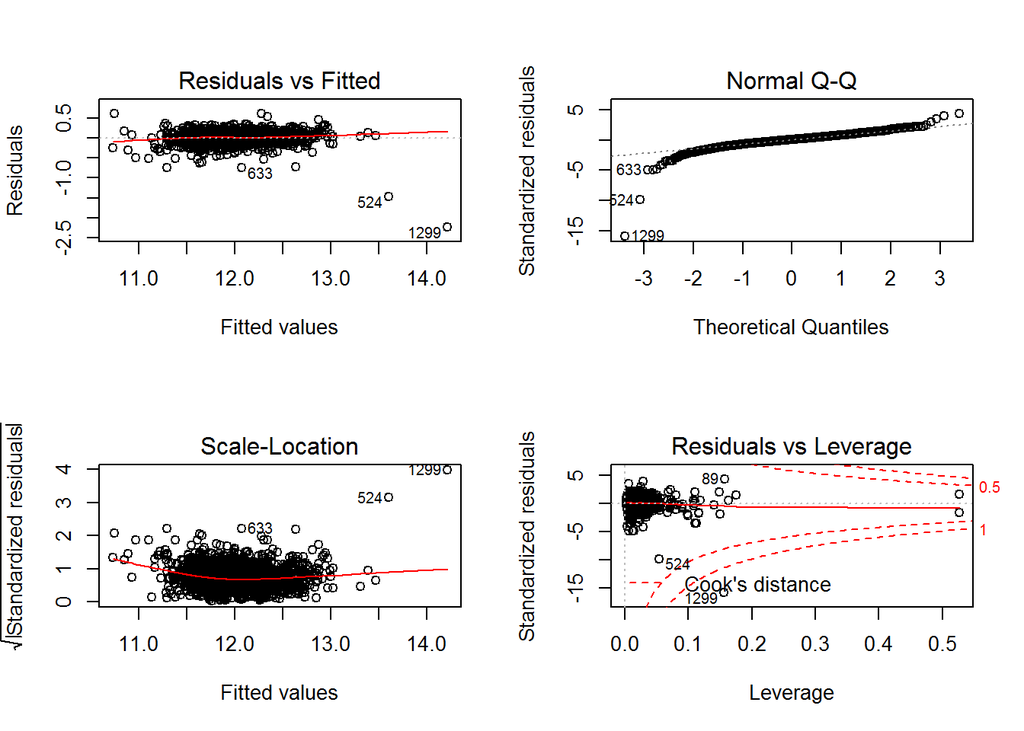

```r
par(mfrow = c(2, 2))
plot(final_model)
```

Analysis of Variance:

```r
aov(final_model)
```

```
## Call:
##    aov(formula = final_model)
##
## Terms:
##                  BsmtQual  BsmtCond ExterQual MasVnrArea log(LotArea)  MSZoning
## Sum of Squares  101.55110   1.83737  23.27046    6.97037     22.14640   3.93568
## Deg. of Freedom         3         3         3          1            1         4
##                 OverallQual OverallCond `1stFlrSF` `2ndFlrSF` TotalBsmtSF
## Sum of Squares     22.75413     1.97776    3.68941    6.51427     0.57068
## Deg. of Freedom           1           1          1          1           1
##                 BedroomAbvGr KitchenAbvGr GarageArea Residuals
## Sum of Squares       0.02678      0.30436    2.24094  33.63251
## Deg. of Freedom            1            1          1      1428
##
## Residual standard error: 0.1534672
## Estimated effects may be unbalanced
## 8 observations deleted due to missingness
```

Detect MultiCollinearity:

```r
vif(final_model)
```

```
##                  GVIF Df GVIF^(1/(2*Df))
## BsmtQual     3.522642  3        1.233516
## BsmtCond     1.293364  3        1.043807
## ExterQual    3.764677  3        1.247253
## MasVnrArea   1.395887  1        1.181477
## log(LotArea) 1.704788  1        1.305675
## MSZoning     1.863832  4        1.080938
## OverallQual  3.457228  1        1.859362
## OverallCond  1.251237  1        1.118587
## `1stFlrSF`   4.124472  1        2.030880
## `2ndFlrSF`   2.327432  1        1.525592
## TotalBsmtSF  3.620984  1        1.902888
## BedroomAbvGr 1.781615  1        1.334771
## KitchenAbvGr 1.208596  1        1.099362
## GarageArea   1.823377  1        1.350325
```

Model selection using AIC:

```r
AIC_final_model <- stepAIC(final_model,direction = "backward",k=2, trace = 0, steps = 1000)
summary(AIC_final_model)
```

```
##
## Call:
## lm(formula = log(SalePrice) ~ BsmtQual + BsmtCond + ExterQual +
##     MasVnrArea + log(LotArea) + MSZoning + OverallQual + OverallCond +
##     `1stFlrSF` + `2ndFlrSF` + TotalBsmtSF + KitchenAbvGr + GarageArea,
##     data = df_ames)
##
## Residuals:
##      Min       1Q   Median       3Q      Max
## -2.23563 -0.06782  0.00964  0.08221  0.60664
##
## Coefficients:
##                Estimate Std. Error t value Pr(>|t|)
## (Intercept)   9.760e+00  1.132e-01  86.252  < 2e-16 ***
## BsmtQualFa   -2.664e-01  3.525e-02  -7.556 7.36e-14 ***
## BsmtQualGd   -1.007e-01  1.882e-02  -5.352 1.01e-07 ***
## BsmtQualTA   -2.018e-01  2.176e-02  -9.277  < 2e-16 ***
## BsmtCondGd    7.480e-02  3.148e-02   2.376 0.017641 *
## BsmtCondPo   -5.076e-02  1.161e-01  -0.437 0.661939
## BsmtCondTA    6.973e-02  2.454e-02   2.841 0.004561 **
## ExterQualFa  -7.531e-02  5.451e-02  -1.381 0.167372
## ExterQualGd   2.812e-02  2.692e-02   1.045 0.296351
## ExterQualTA  -4.330e-02  2.954e-02  -1.466 0.142858
## MasVnrArea    5.758e-05  2.628e-05   2.191 0.028592 *
## log(LotArea)  7.682e-02  1.013e-02   7.585 5.95e-14 ***
## MSZoningFV    5.042e-01  5.525e-02   9.127  < 2e-16 ***
## MSZoningRH    4.331e-01  6.310e-02   6.864 9.93e-12 ***
## MSZoningRL    4.698e-01  5.116e-02   9.183  < 2e-16 ***
## MSZoningRM    3.517e-01  5.199e-02   6.764 1.95e-11 ***
## OverallQual   8.576e-02  5.420e-03  15.822  < 2e-16 ***
## OverallCond   4.223e-02  4.045e-03  10.441  < 2e-16 ***
## `1stFlrSF`    2.210e-04  2.086e-05  10.595  < 2e-16 ***
## `2ndFlrSF`    2.003e-04  1.171e-05  17.104  < 2e-16 ***
## TotalBsmtSF   7.365e-05  1.748e-05   4.214 2.67e-05 ***
## KitchenAbvGr -7.392e-02  2.004e-02  -3.689 0.000233 ***
## GarageArea    2.477e-04  2.533e-05   9.779  < 2e-16 ***
## ---
## Signif. codes:  0 '***' 0.001 '**' 0.01 '*' 0.05 '.' 0.1 ' ' 1
##
## Residual standard error: 0.1534 on 1429 degrees of freedom
##   (8 observations deleted due to missingness)
## Multiple R-squared:  0.8547, Adjusted R-squared:  0.8524
## F-statistic:   382 on 22 and 1429 DF,  p-value: < 2.2e-16
```